```python
import pandas as pd
import numpy as np
import matplotlib.pyplot as plt
%matplotlib inline
import requests
import tweepy
import json
```

# Gathering Data

#### 1.The WeRateDogs Twitter archive

```python
# upload the file into Jupter notebook, then read the file
twitter_archive = pd.read_csv('twitter-archive-enhanced.csv')
```

```python
twitter_archive.head()
```

|  | tweet_id | in_reply_to_status_id | in_reply_to_user_id | timestamp | source | text | retweeted_status_id | retweeted_status_user_id | retweeted_status_timestamp | expanded_urls | rating_numerator | rating_denominator | name | doggo | floofer | pupper | puppo |
| --- | --- | --- | --- | --- | --- | --- | --- | --- | --- | --- | --- | --- | --- | --- | --- | --- | --- |
| 0 | 892420643555336193 | NaN | NaN | 2017-08-01 16:23:56 +0000 | <a href="http://twitter.com/download/iphone" r... | This is Phineas. He's a mystical boy. Only eve... | NaN | NaN | NaN | https://twitter.com/dog_rates/status/892420643... | 13 | 10 | Phineas | None | None | None | None |
| 1 | 892177421306343426 | NaN | NaN | 2017-08-01 00:17:27 +0000 | <a href="http://twitter.com/download/iphone" r... | This is Tilly. She's just checking pup on you.... | NaN | NaN | NaN | https://twitter.com/dog_rates/status/892177421... | 13 | 10 | Tilly | None | None | None | None |
| 2 | 891815181378084864 | NaN | NaN | 2017-07-31 00:18:03 +0000 | <a href="http://twitter.com/download/iphone" r... | This is Archie. He is a rare Norwegian Pouncin... | NaN | NaN | NaN | https://twitter.com/dog_rates/status/891815181... | 12 | 10 | Archie | None | None | None | None |
| 3 | 891689557279858688 | NaN | NaN | 2017-07-30 15:58:51 +0000 | <a href="http://twitter.com/download/iphone" r... | This is Darla. She commenced a snooze mid meal... | NaN | NaN | NaN | https://twitter.com/dog_rates/status/891689557... | 13 | 10 | Darla | None | None | None | None |
| 4 | 891327558926688256 | NaN | NaN | 2017-07-29 16:00:24 +0000 | <a href="http://twitter.com/download/iphone" r... | This is Franklin. He would like you to stop ca... | NaN | NaN | NaN | https://twitter.com/dog_rates/status/891327558... | 12 | 10 | Franklin | None | None | None | None |

```python
twitter_archive.describe()
```

|  | tweet_id | in_reply_to_status_id | in_reply_to_user_id | retweeted_status_id | retweeted_status_user_id | rating_numerator | rating_denominator |
| --- | --- | --- | --- | --- | --- | --- | --- |
| count | 2.356000e+03 | 7.800000e+01 | 7.800000e+01 | 1.810000e+02 | 1.810000e+02 | 2356.000000 | 2356.000000 |
| mean | 7.427716e+17 | 7.455079e+17 | 2.014171e+16 | 7.720400e+17 | 1.241698e+16 | 13.126486 | 10.455433 |
| std | 6.856705e+16 | 7.582492e+16 | 1.252797e+17 | 6.236928e+16 | 9.599254e+16 | 45.876648 | 6.745237 |
| min | 6.660209e+17 | 6.658147e+17 | 1.185634e+07 | 6.661041e+17 | 7.832140e+05 | 0.000000 | 0.000000 |
| 25% | 6.783989e+17 | 6.757419e+17 | 3.086374e+08 | 7.186315e+17 | 4.196984e+09 | 10.000000 | 10.000000 |
| 50% | 7.196279e+17 | 7.038708e+17 | 4.196984e+09 | 7.804657e+17 | 4.196984e+09 | 11.000000 | 10.000000 |
| 75% | 7.993373e+17 | 8.257804e+17 | 4.196984e+09 | 8.203146e+17 | 4.196984e+09 | 12.000000 | 10.000000 |
| max | 8.924206e+17 | 8.862664e+17 | 8.405479e+17 | 8.874740e+17 | 7.874618e+17 | 1776.000000 | 170.000000 |

```python
twitter_archive.info()
```

```
<class 'pandas.core.frame.DataFrame'>
RangeIndex: 2356 entries, 0 to 2355
Data columns (total 17 columns):
tweet_id                      2356 non-null int64
in_reply_to_status_id         78 non-null float64
in_reply_to_user_id           78 non-null float64
timestamp                     2356 non-null object
source                        2356 non-null object
text                          2356 non-null object
retweeted_status_id           181 non-null float64
retweeted_status_user_id      181 non-null float64
retweeted_status_timestamp    181 non-null object
expanded_urls                 2297 non-null object
rating_numerator              2356 non-null int64
rating_denominator            2356 non-null int64
name                          2356 non-null object
doggo                         2356 non-null object
floofer                       2356 non-null object
pupper                        2356 non-null object
puppo                         2356 non-null object
dtypes: float64(4), int64(3), object(10)
memory usage: 313.0+ KB
```

#### 2.The image predictions

```python
# download programatically
url = "https://d17h27t6h515a5.cloudfront.net/topher/2017/August/599fd2ad_image-predictions/image-predictions.tsv"
response = requests.get(url)

with open('image-predictions.tsv', mode ='wb') as file:
    file.write(response.content)
```

```python
# Read the tsv file
image_prediction = pd.read_csv('image-predictions.tsv', sep='\t' )
image_prediction.head()
```

|  | tweet_id | jpg_url | img_num | p1 | p1_conf | p1_dog | p2 | p2_conf | p2_dog | p3 | p3_conf | p3_dog |
| --- | --- | --- | --- | --- | --- | --- | --- | --- | --- | --- | --- | --- |
| 0 | 666020888022790149 | https://pbs.twimg.com/media/CT4udn0WwAA0aMy.jpg | 1 | Welsh_springer_spaniel | 0.465074 | True | collie | 0.156665 | True | Shetland_sheepdog | 0.061428 | True |
| 1 | 666029285002620928 | https://pbs.twimg.com/media/CT42GRgUYAA5iDo.jpg | 1 | redbone | 0.506826 | True | miniature_pinscher | 0.074192 | True | Rhodesian_ridgeback | 0.072010 | True |
| 2 | 666033412701032449 | https://pbs.twimg.com/media/CT4521TWwAEvMyu.jpg | 1 | German_shepherd | 0.596461 | True | malinois | 0.138584 | True | bloodhound | 0.116197 | True |
| 3 | 666044226329800704 | https://pbs.twimg.com/media/CT5Dr8HUEAA-lEu.jpg | 1 | Rhodesian_ridgeback | 0.408143 | True | redbone | 0.360687 | True | miniature_pinscher | 0.222752 | True |
| 4 | 666049248165822465 | https://pbs.twimg.com/media/CT5IQmsXIAAKY4A.jpg | 1 | miniature_pinscher | 0.560311 | True | Rottweiler | 0.243682 | True | Doberman | 0.154629 | True |

#### 3. Each tweet's retweet count and other additional data

```python
# query the Twitter API for each tweet's JSON data using Python's Tweepy library
consumer_key = 'Ad0VGCZoW6Tzf7UzmtJUQU6jR'
consumer_secret = '4M8ACfCaRU17V6XqRaUHjnZGeXfB0mGcamveDsyX2apRa8r1zB'
access_token = '1623315782-HM3pUHNi2BKjra1sY76M7OFPxTM53ieBU7KAaMd'
access_secret = 'GTELieAwaEIKOrlRNmJO99Kh1bcGYZSnfGXMvTmNbIi3J'

auth = tweepy.OAuthHandler(consumer_key, consumer_secret)
auth.set_access_token(access_token, access_secret)

api = tweepy.API(auth,
                 parser = tweepy.parsers.JSONParser(),
                 wait_on_rate_limit = True,
                 wait_on_rate_limit_notify = True)
```

```python
#Download Tweepy status object based on tweet_id
list_of_tweets = []
cant_find_tweets_for_those_ids = []
for tweet_id in twitter_archive['tweet_id']:
    try:
        list_of_tweets.append(api.get_status(tweet_id))
    except Exception as e:
        cant_find_tweets_for_those_ids.append(tweet_id)
```

```
Rate limit reached. Sleeping for: 740
Rate limit reached. Sleeping for: 739
```

```python
# to see how many tweet ids are found in the api
len(list_of_tweets)
```

```
2332
```

```python
# # to see how many tweet ids are not found in the api
len(cant_find_tweets_for_those_ids)
```

```
24
```

```python
# get the json part of each tweepy status object and add them all into lists
lists = []
for each_json_tweet in list_of_tweets:
    lists.append(each_json_tweet)
```

```python
# store each tweet's entire set of JSON data in tweet_json.txt file.

with open('tweet_json.txt', 'w') as file:
        file.write(json.dumps(lists, indent=4))
```

```python
# get information and create a dataframe
list_second = []
with open('tweet_json.txt', encoding='utf-8') as json_file:
    data_injsonfile = json.load(json_file)
    for dic_1 in data_injsonfile:
        tweet_id = dic_1['id']
        favorite_count = dic_1['favorite_count']
        retweet_count = dic_1['retweet_count']
        followers_count = dic_1['user']['followers_count']
        friends_count = dic_1['user']['friends_count']

        list_second.append({'tweet_id': str(tweet_id),
                             'favorite_count': int(favorite_count),
                             'retweet_count': int(retweet_count),
                             'followers_count': int(followers_count),
                             'friends_count': int(friends_count),
                             })
        tweet_json = pd.DataFrame(list_second, columns = ['tweet_id', 'favorite_count','retweet_count',
                                                           'followers_count', 'friends_count'])
```

```python
tweet_json.head()
```

|  | tweet_id | favorite_count | retweet_count | followers_count | friends_count |
| --- | --- | --- | --- | --- | --- |
| 0 | 892420643555336193 | 36039 | 7673 | 8781558 | 16 |
| 1 | 892177421306343426 | 31090 | 5674 | 8781558 | 16 |
| 2 | 891815181378084864 | 23398 | 3761 | 8781558 | 16 |
| 3 | 891689557279858688 | 39316 | 7848 | 8781558 | 16 |
| 4 | 891327558926688256 | 37552 | 8446 | 8781558 | 16 |

```python
tweet_json.info()
```

```
<class 'pandas.core.frame.DataFrame'>
RangeIndex: 2332 entries, 0 to 2331
Data columns (total 5 columns):
tweet_id           2332 non-null object
favorite_count     2332 non-null int64
retweet_count      2332 non-null int64
followers_count    2332 non-null int64
friends_count      2332 non-null int64
dtypes: int64(4), object(1)
memory usage: 91.2+ KB
```

## Assessing data

### 1.Visual assessment

```python
twitter_archive
```

|  | tweet_id | in_reply_to_status_id | in_reply_to_user_id | timestamp | source | text | retweeted_status_id | retweeted_status_user_id | retweeted_status_timestamp | expanded_urls | rating_numerator | rating_denominator | name | doggo | floofer | pupper | puppo |
| --- | --- | --- | --- | --- | --- | --- | --- | --- | --- | --- | --- | --- | --- | --- | --- | --- | --- |
| 0 | 892420643555336193 | NaN | NaN | 2017-08-01 16:23:56 +0000 | <a href="http://twitter.com/download/iphone" r... | This is Phineas. He's a mystical boy. Only eve... | NaN | NaN | NaN | https://twitter.com/dog_rates/status/892420643... | 13 | 10 | Phineas | None | None | None | None |
| 1 | 892177421306343426 | NaN | NaN | 2017-08-01 00:17:27 +0000 | <a href="http://twitter.com/download/iphone" r... | This is Tilly. She's just checking pup on you.... | NaN | NaN | NaN | https://twitter.com/dog_rates/status/892177421... | 13 | 10 | Tilly | None | None | None | None |
| 2 | 891815181378084864 | NaN | NaN | 2017-07-31 00:18:03 +0000 | <a href="http://twitter.com/download/iphone" r... | This is Archie. He is a rare Norwegian Pouncin... | NaN | NaN | NaN | https://twitter.com/dog_rates/status/891815181... | 12 | 10 | Archie | None | None | None | None |
| 3 | 891689557279858688 | NaN | NaN | 2017-07-30 15:58:51 +0000 | <a href="http://twitter.com/download/iphone" r... | This is Darla. She commenced a snooze mid meal... | NaN | NaN | NaN | https://twitter.com/dog_rates/status/891689557... | 13 | 10 | Darla | None | None | None | None |
| 4 | 891327558926688256 | NaN | NaN | 2017-07-29 16:00:24 +0000 | <a href="http://twitter.com/download/iphone" r... | This is Franklin. He would like you to stop ca... | NaN | NaN | NaN | https://twitter.com/dog_rates/status/891327558... | 12 | 10 | Franklin | None | None | None | None |
| 5 | 891087950875897856 | NaN | NaN | 2017-07-29 00:08:17 +0000 | <a href="http://twitter.com/download/iphone" r... | Here we have a majestic great white breaching ... | NaN | NaN | NaN | https://twitter.com/dog_rates/status/891087950... | 13 | 10 | None | None | None | None | None |
| 6 | 890971913173991426 | NaN | NaN | 2017-07-28 16:27:12 +0000 | <a href="http://twitter.com/download/iphone" r... | Meet Jax. He enjoys ice cream so much he gets ... | NaN | NaN | NaN | https://gofundme.com/ydvmve-surgery-for-jax,ht... | 13 | 10 | Jax | None | None | None | None |
| 7 | 890729181411237888 | NaN | NaN | 2017-07-28 00:22:40 +0000 | <a href="http://twitter.com/download/iphone" r... | When you watch your owner call another dog a g... | NaN | NaN | NaN | https://twitter.com/dog_rates/status/890729181... | 13 | 10 | None | None | None | None | None |
| 8 | 890609185150312448 | NaN | NaN | 2017-07-27 16:25:51 +0000 | <a href="http://twitter.com/download/iphone" r... | This is Zoey. She doesn't want to be one of th... | NaN | NaN | NaN | https://twitter.com/dog_rates/status/890609185... | 13 | 10 | Zoey | None | None | None | None |
| 9 | 890240255349198849 | NaN | NaN | 2017-07-26 15:59:51 +0000 | <a href="http://twitter.com/download/iphone" r... | This is Cassie. She is a college pup. Studying... | NaN | NaN | NaN | https://twitter.com/dog_rates/status/890240255... | 14 | 10 | Cassie | doggo | None | None | None |
| 10 | 890006608113172480 | NaN | NaN | 2017-07-26 00:31:25 +0000 | <a href="http://twitter.com/download/iphone" r... | This is Koda. He is a South Australian decksha... | NaN | NaN | NaN | https://twitter.com/dog_rates/status/890006608... | 13 | 10 | Koda | None | None | None | None |
| 11 | 889880896479866881 | NaN | NaN | 2017-07-25 16:11:53 +0000 | <a href="http://twitter.com/download/iphone" r... | This is Bruno. He is a service shark. Only get... | NaN | NaN | NaN | https://twitter.com/dog_rates/status/889880896... | 13 | 10 | Bruno | None | None | None | None |
| 12 | 889665388333682689 | NaN | NaN | 2017-07-25 01:55:32 +0000 | <a href="http://twitter.com/download/iphone" r... | Here's a puppo that seems to be on the fence a... | NaN | NaN | NaN | https://twitter.com/dog_rates/status/889665388... | 13 | 10 | None | None | None | None | puppo |
| 13 | 889638837579907072 | NaN | NaN | 2017-07-25 00:10:02 +0000 | <a href="http://twitter.com/download/iphone" r... | This is Ted. He does his best. Sometimes that'... | NaN | NaN | NaN | https://twitter.com/dog_rates/status/889638837... | 12 | 10 | Ted | None | None | None | None |
| 14 | 889531135344209921 | NaN | NaN | 2017-07-24 17:02:04 +0000 | <a href="http://twitter.com/download/iphone" r... | This is Stuart. He's sporting his favorite fan... | NaN | NaN | NaN | https://twitter.com/dog_rates/status/889531135... | 13 | 10 | Stuart | None | None | None | puppo |
| 15 | 889278841981685760 | NaN | NaN | 2017-07-24 00:19:32 +0000 | <a href="http://twitter.com/download/iphone" r... | This is Oliver. You're witnessing one of his m... | NaN | NaN | NaN | https://twitter.com/dog_rates/status/889278841... | 13 | 10 | Oliver | None | None | None | None |
| 16 | 888917238123831296 | NaN | NaN | 2017-07-23 00:22:39 +0000 | <a href="http://twitter.com/download/iphone" r... | This is Jim. He found a fren. Taught him how t... | NaN | NaN | NaN | https://twitter.com/dog_rates/status/888917238... | 12 | 10 | Jim | None | None | None | None |
| 17 | 888804989199671297 | NaN | NaN | 2017-07-22 16:56:37 +0000 | <a href="http://twitter.com/download/iphone" r... | This is Zeke. He has a new stick. Very proud o... | NaN | NaN | NaN | https://twitter.com/dog_rates/status/888804989... | 13 | 10 | Zeke | None | None | None | None |
| 18 | 888554962724278272 | NaN | NaN | 2017-07-22 00:23:06 +0000 | <a href="http://twitter.com/download/iphone" r... | This is Ralphus. He's powering up. Attempting ... | NaN | NaN | NaN | https://twitter.com/dog_rates/status/888554962... | 13 | 10 | Ralphus | None | None | None | None |
| 19 | 888202515573088257 | NaN | NaN | 2017-07-21 01:02:36 +0000 | <a href="http://twitter.com/download/iphone" r... | RT @dog_rates: This is Canela. She attempted s... | 8.874740e+17 | 4.196984e+09 | 2017-07-19 00:47:34 +0000 | https://twitter.com/dog_rates/status/887473957... | 13 | 10 | Canela | None | None | None | None |
| 20 | 888078434458587136 | NaN | NaN | 2017-07-20 16:49:33 +0000 | <a href="http://twitter.com/download/iphone" r... | This is Gerald. He was just told he didn't get... | NaN | NaN | NaN | https://twitter.com/dog_rates/status/888078434... | 12 | 10 | Gerald | None | None | None | None |
| 21 | 887705289381826560 | NaN | NaN | 2017-07-19 16:06:48 +0000 | <a href="http://twitter.com/download/iphone" r... | This is Jeffrey. He has a monopoly on the pool... | NaN | NaN | NaN | https://twitter.com/dog_rates/status/887705289... | 13 | 10 | Jeffrey | None | None | None | None |
| 22 | 887517139158093824 | NaN | NaN | 2017-07-19 03:39:09 +0000 | <a href="http://twitter.com/download/iphone" r... | I've yet to rate a Venezuelan Hover Wiener. Th... | NaN | NaN | NaN | https://twitter.com/dog_rates/status/887517139... | 14 | 10 | such | None | None | None | None |
| 23 | 887473957103951883 | NaN | NaN | 2017-07-19 00:47:34 +0000 | <a href="http://twitter.com/download/iphone" r... | This is Canela. She attempted some fancy porch... | NaN | NaN | NaN | https://twitter.com/dog_rates/status/887473957... | 13 | 10 | Canela | None | None | None | None |
| 24 | 887343217045368832 | NaN | NaN | 2017-07-18 16:08:03 +0000 | <a href="http://twitter.com/download/iphone" r... | You may not have known you needed to see this ... | NaN | NaN | NaN | https://twitter.com/dog_rates/status/887343217... | 13 | 10 | None | None | None | None | None |
| 25 | 887101392804085760 | NaN | NaN | 2017-07-18 00:07:08 +0000 | <a href="http://twitter.com/download/iphone" r... | This... is a Jubilant Antarctic House Bear. We... | NaN | NaN | NaN | https://twitter.com/dog_rates/status/887101392... | 12 | 10 | None | None | None | None | None |
| 26 | 886983233522544640 | NaN | NaN | 2017-07-17 16:17:36 +0000 | <a href="http://twitter.com/download/iphone" r... | This is Maya. She's very shy. Rarely leaves he... | NaN | NaN | NaN | https://twitter.com/dog_rates/status/886983233... | 13 | 10 | Maya | None | None | None | None |
| 27 | 886736880519319552 | NaN | NaN | 2017-07-16 23:58:41 +0000 | <a href="http://twitter.com/download/iphone" r... | This is Mingus. He's a wonderful father to his... | NaN | NaN | NaN | https://www.gofundme.com/mingusneedsus,https:/... | 13 | 10 | Mingus | None | None | None | None |
| 28 | 886680336477933568 | NaN | NaN | 2017-07-16 20:14:00 +0000 | <a href="http://twitter.com/download/iphone" r... | This is Derek. He's late for a dog meeting. 13... | NaN | NaN | NaN | https://twitter.com/dog_rates/status/886680336... | 13 | 10 | Derek | None | None | None | None |
| 29 | 886366144734445568 | NaN | NaN | 2017-07-15 23:25:31 +0000 | <a href="http://twitter.com/download/iphone" r... | This is Roscoe. Another pupper fallen victim t... | NaN | NaN | NaN | https://twitter.com/dog_rates/status/886366144... | 12 | 10 | Roscoe | None | None | pupper | None |
| ... | ... | ... | ... | ... | ... | ... | ... | ... | ... | ... | ... | ... | ... | ... | ... | ... | ... |
| 2326 | 666411507551481857 | NaN | NaN | 2015-11-17 00:24:19 +0000 | <a href="http://twitter.com/download/iphone" r... | This is quite the dog. Gets really excited whe... | NaN | NaN | NaN | https://twitter.com/dog_rates/status/666411507... | 2 | 10 | quite | None | None | None | None |
| 2327 | 666407126856765440 | NaN | NaN | 2015-11-17 00:06:54 +0000 | <a href="http://twitter.com/download/iphone" r... | This is a southern Vesuvius bumblegruff. Can d... | NaN | NaN | NaN | https://twitter.com/dog_rates/status/666407126... | 7 | 10 | a | None | None | None | None |
| 2328 | 666396247373291520 | NaN | NaN | 2015-11-16 23:23:41 +0000 | <a href="http://twitter.com/download/iphone" r... | Oh goodness. A super rare northeast Qdoba kang... | NaN | NaN | NaN | https://twitter.com/dog_rates/status/666396247... | 9 | 10 | None | None | None | None | None |
| 2329 | 666373753744588802 | NaN | NaN | 2015-11-16 21:54:18 +0000 | <a href="http://twitter.com/download/iphone" r... | Those are sunglasses and a jean jacket. 11/10 ... | NaN | NaN | NaN | https://twitter.com/dog_rates/status/666373753... | 11 | 10 | None | None | None | None | None |
| 2330 | 666362758909284353 | NaN | NaN | 2015-11-16 21:10:36 +0000 | <a href="http://twitter.com/download/iphone" r... | Unique dog here. Very small. Lives in containe... | NaN | NaN | NaN | https://twitter.com/dog_rates/status/666362758... | 6 | 10 | None | None | None | None | None |
| 2331 | 666353288456101888 | NaN | NaN | 2015-11-16 20:32:58 +0000 | <a href="http://twitter.com/download/iphone" r... | Here we have a mixed Asiago from the Galápagos... | NaN | NaN | NaN | https://twitter.com/dog_rates/status/666353288... | 8 | 10 | None | None | None | None | None |
| 2332 | 666345417576210432 | NaN | NaN | 2015-11-16 20:01:42 +0000 | <a href="http://twitter.com/download/iphone" r... | Look at this jokester thinking seat belt laws ... | NaN | NaN | NaN | https://twitter.com/dog_rates/status/666345417... | 10 | 10 | None | None | None | None | None |
| 2333 | 666337882303524864 | NaN | NaN | 2015-11-16 19:31:45 +0000 | <a href="http://twitter.com/download/iphone" r... | This is an extremely rare horned Parthenon. No... | NaN | NaN | NaN | https://twitter.com/dog_rates/status/666337882... | 9 | 10 | an | None | None | None | None |
| 2334 | 666293911632134144 | NaN | NaN | 2015-11-16 16:37:02 +0000 | <a href="http://twitter.com/download/iphone" r... | This is a funny dog. Weird toes. Won't come do... | NaN | NaN | NaN | https://twitter.com/dog_rates/status/666293911... | 3 | 10 | a | None | None | None | None |
| 2335 | 666287406224695296 | NaN | NaN | 2015-11-16 16:11:11 +0000 | <a href="http://twitter.com/download/iphone" r... | This is an Albanian 3 1/2 legged Episcopalian... | NaN | NaN | NaN | https://twitter.com/dog_rates/status/666287406... | 1 | 2 | an | None | None | None | None |
| 2336 | 666273097616637952 | NaN | NaN | 2015-11-16 15:14:19 +0000 | <a href="http://twitter.com/download/iphone" r... | Can take selfies 11/10 https://t.co/ws2AMaNwPW | NaN | NaN | NaN | https://twitter.com/dog_rates/status/666273097... | 11 | 10 | None | None | None | None | None |
| 2337 | 666268910803644416 | NaN | NaN | 2015-11-16 14:57:41 +0000 | <a href="http://twitter.com/download/iphone" r... | Very concerned about fellow dog trapped in com... | NaN | NaN | NaN | https://twitter.com/dog_rates/status/666268910... | 10 | 10 | None | None | None | None | None |
| 2338 | 666104133288665088 | NaN | NaN | 2015-11-16 04:02:55 +0000 | <a href="http://twitter.com/download/iphone" r... | Not familiar with this breed. No tail (weird).... | NaN | NaN | NaN | https://twitter.com/dog_rates/status/666104133... | 1 | 10 | None | None | None | None | None |
| 2339 | 666102155909144576 | NaN | NaN | 2015-11-16 03:55:04 +0000 | <a href="http://twitter.com/download/iphone" r... | Oh my. Here you are seeing an Adobe Setter giv... | NaN | NaN | NaN | https://twitter.com/dog_rates/status/666102155... | 11 | 10 | None | None | None | None | None |
| 2340 | 666099513787052032 | NaN | NaN | 2015-11-16 03:44:34 +0000 | <a href="http://twitter.com/download/iphone" r... | Can stand on stump for what seems like a while... | NaN | NaN | NaN | https://twitter.com/dog_rates/status/666099513... | 8 | 10 | None | None | None | None | None |
| 2341 | 666094000022159362 | NaN | NaN | 2015-11-16 03:22:39 +0000 | <a href="http://twitter.com/download/iphone" r... | This appears to be a Mongolian Presbyterian mi... | NaN | NaN | NaN | https://twitter.com/dog_rates/status/666094000... | 9 | 10 | None | None | None | None | None |
| 2342 | 666082916733198337 | NaN | NaN | 2015-11-16 02:38:37 +0000 | <a href="http://twitter.com/download/iphone" r... | Here we have a well-established sunblockerspan... | NaN | NaN | NaN | https://twitter.com/dog_rates/status/666082916... | 6 | 10 | None | None | None | None | None |
| 2343 | 666073100786774016 | NaN | NaN | 2015-11-16 01:59:36 +0000 | <a href="http://twitter.com/download/iphone" r... | Let's hope this flight isn't Malaysian (lol). ... | NaN | NaN | NaN | https://twitter.com/dog_rates/status/666073100... | 10 | 10 | None | None | None | None | None |
| 2344 | 666071193221509120 | NaN | NaN | 2015-11-16 01:52:02 +0000 | <a href="http://twitter.com/download/iphone" r... | Here we have a northern speckled Rhododendron.... | NaN | NaN | NaN | https://twitter.com/dog_rates/status/666071193... | 9 | 10 | None | None | None | None | None |
| 2345 | 666063827256086533 | NaN | NaN | 2015-11-16 01:22:45 +0000 | <a href="http://twitter.com/download/iphone" r... | This is the happiest dog you will ever see. Ve... | NaN | NaN | NaN | https://twitter.com/dog_rates/status/666063827... | 10 | 10 | the | None | None | None | None |
| 2346 | 666058600524156928 | NaN | NaN | 2015-11-16 01:01:59 +0000 | <a href="http://twitter.com/download/iphone" r... | Here is the Rand Paul of retrievers folks! He'... | NaN | NaN | NaN | https://twitter.com/dog_rates/status/666058600... | 8 | 10 | the | None | None | None | None |
| 2347 | 666057090499244032 | NaN | NaN | 2015-11-16 00:55:59 +0000 | <a href="http://twitter.com/download/iphone" r... | My oh my. This is a rare blond Canadian terrie... | NaN | NaN | NaN | https://twitter.com/dog_rates/status/666057090... | 9 | 10 | a | None | None | None | None |
| 2348 | 666055525042405380 | NaN | NaN | 2015-11-16 00:49:46 +0000 | <a href="http://twitter.com/download/iphone" r... | Here is a Siberian heavily armored polar bear ... | NaN | NaN | NaN | https://twitter.com/dog_rates/status/666055525... | 10 | 10 | a | None | None | None | None |
| 2349 | 666051853826850816 | NaN | NaN | 2015-11-16 00:35:11 +0000 | <a href="http://twitter.com/download/iphone" r... | This is an odd dog. Hard on the outside but lo... | NaN | NaN | NaN | https://twitter.com/dog_rates/status/666051853... | 2 | 10 | an | None | None | None | None |
| 2350 | 666050758794694657 | NaN | NaN | 2015-11-16 00:30:50 +0000 | <a href="http://twitter.com/download/iphone" r... | This is a truly beautiful English Wilson Staff... | NaN | NaN | NaN | https://twitter.com/dog_rates/status/666050758... | 10 | 10 | a | None | None | None | None |
| 2351 | 666049248165822465 | NaN | NaN | 2015-11-16 00:24:50 +0000 | <a href="http://twitter.com/download/iphone" r... | Here we have a 1949 1st generation vulpix. Enj... | NaN | NaN | NaN | https://twitter.com/dog_rates/status/666049248... | 5 | 10 | None | None | None | None | None |
| 2352 | 666044226329800704 | NaN | NaN | 2015-11-16 00:04:52 +0000 | <a href="http://twitter.com/download/iphone" r... | This is a purebred Piers Morgan. Loves to Netf... | NaN | NaN | NaN | https://twitter.com/dog_rates/status/666044226... | 6 | 10 | a | None | None | None | None |
| 2353 | 666033412701032449 | NaN | NaN | 2015-11-15 23:21:54 +0000 | <a href="http://twitter.com/download/iphone" r... | Here is a very happy pup. Big fan of well-main... | NaN | NaN | NaN | https://twitter.com/dog_rates/status/666033412... | 9 | 10 | a | None | None | None | None |
| 2354 | 666029285002620928 | NaN | NaN | 2015-11-15 23:05:30 +0000 | <a href="http://twitter.com/download/iphone" r... | This is a western brown Mitsubishi terrier. Up... | NaN | NaN | NaN | https://twitter.com/dog_rates/status/666029285... | 7 | 10 | a | None | None | None | None |
| 2355 | 666020888022790149 | NaN | NaN | 2015-11-15 22:32:08 +0000 | <a href="http://twitter.com/download/iphone" r... | Here we have a Japanese Irish Setter. Lost eye... | NaN | NaN | NaN | https://twitter.com/dog_rates/status/666020888... | 8 | 10 | None | None | None | None | None |

2356 rows × 17 columns

```python
image_prediction
```

|  | tweet_id | jpg_url | img_num | p1 | p1_conf | p1_dog | p2 | p2_conf | p2_dog | p3 | p3_conf | p3_dog |
| --- | --- | --- | --- | --- | --- | --- | --- | --- | --- | --- | --- | --- |
| 0 | 666020888022790149 | https://pbs.twimg.com/media/CT4udn0WwAA0aMy.jpg | 1 | Welsh_springer_spaniel | 0.465074 | True | collie | 0.156665 | True | Shetland_sheepdog | 0.061428 | True |
| 1 | 666029285002620928 | https://pbs.twimg.com/media/CT42GRgUYAA5iDo.jpg | 1 | redbone | 0.506826 | True | miniature_pinscher | 0.074192 | True | Rhodesian_ridgeback | 0.072010 | True |
| 2 | 666033412701032449 | https://pbs.twimg.com/media/CT4521TWwAEvMyu.jpg | 1 | German_shepherd | 0.596461 | True | malinois | 0.138584 | True | bloodhound | 0.116197 | True |
| 3 | 666044226329800704 | https://pbs.twimg.com/media/CT5Dr8HUEAA-lEu.jpg | 1 | Rhodesian_ridgeback | 0.408143 | True | redbone | 0.360687 | True | miniature_pinscher | 0.222752 | True |
| 4 | 666049248165822465 | https://pbs.twimg.com/media/CT5IQmsXIAAKY4A.jpg | 1 | miniature_pinscher | 0.560311 | True | Rottweiler | 0.243682 | True | Doberman | 0.154629 | True |
| 5 | 666050758794694657 | https://pbs.twimg.com/media/CT5Jof1WUAEuVxN.jpg | 1 | Bernese_mountain_dog | 0.651137 | True | English_springer | 0.263788 | True | Greater_Swiss_Mountain_dog | 0.016199 | True |
| 6 | 666051853826850816 | https://pbs.twimg.com/media/CT5KoJ1WoAAJash.jpg | 1 | box_turtle | 0.933012 | False | mud_turtle | 0.045885 | False | terrapin | 0.017885 | False |
| 7 | 666055525042405380 | https://pbs.twimg.com/media/CT5N9tpXIAAifs1.jpg | 1 | chow | 0.692517 | True | Tibetan_mastiff | 0.058279 | True | fur_coat | 0.054449 | False |
| 8 | 666057090499244032 | https://pbs.twimg.com/media/CT5PY90WoAAQGLo.jpg | 1 | shopping_cart | 0.962465 | False | shopping_basket | 0.014594 | False | golden_retriever | 0.007959 | True |
| 9 | 666058600524156928 | https://pbs.twimg.com/media/CT5Qw94XAAA_2dP.jpg | 1 | miniature_poodle | 0.201493 | True | komondor | 0.192305 | True | soft-coated_wheaten_terrier | 0.082086 | True |
| 10 | 666063827256086533 | https://pbs.twimg.com/media/CT5Vg_wXIAAXfnj.jpg | 1 | golden_retriever | 0.775930 | True | Tibetan_mastiff | 0.093718 | True | Labrador_retriever | 0.072427 | True |
| 11 | 666071193221509120 | https://pbs.twimg.com/media/CT5cN_3WEAAlOoZ.jpg | 1 | Gordon_setter | 0.503672 | True | Yorkshire_terrier | 0.174201 | True | Pekinese | 0.109454 | True |
| 12 | 666073100786774016 | https://pbs.twimg.com/media/CT5d9DZXAAALcwe.jpg | 1 | Walker_hound | 0.260857 | True | English_foxhound | 0.175382 | True | Ibizan_hound | 0.097471 | True |
| 13 | 666082916733198337 | https://pbs.twimg.com/media/CT5m4VGWEAAtKc8.jpg | 1 | pug | 0.489814 | True | bull_mastiff | 0.404722 | True | French_bulldog | 0.048960 | True |
| 14 | 666094000022159362 | https://pbs.twimg.com/media/CT5w9gUW4AAsBNN.jpg | 1 | bloodhound | 0.195217 | True | German_shepherd | 0.078260 | True | malinois | 0.075628 | True |
| 15 | 666099513787052032 | https://pbs.twimg.com/media/CT51-JJUEAA6hV8.jpg | 1 | Lhasa | 0.582330 | True | Shih-Tzu | 0.166192 | True | Dandie_Dinmont | 0.089688 | True |
| 16 | 666102155909144576 | https://pbs.twimg.com/media/CT54YGiWUAEZnoK.jpg | 1 | English_setter | 0.298617 | True | Newfoundland | 0.149842 | True | borzoi | 0.133649 | True |
| 17 | 666104133288665088 | https://pbs.twimg.com/media/CT56LSZWoAAlJj2.jpg | 1 | hen | 0.965932 | False | cock | 0.033919 | False | partridge | 0.000052 | False |
| 18 | 666268910803644416 | https://pbs.twimg.com/media/CT8QCd1WEAADXws.jpg | 1 | desktop_computer | 0.086502 | False | desk | 0.085547 | False | bookcase | 0.079480 | False |
| 19 | 666273097616637952 | https://pbs.twimg.com/media/CT8T1mtUwAA3aqm.jpg | 1 | Italian_greyhound | 0.176053 | True | toy_terrier | 0.111884 | True | basenji | 0.111152 | True |
| 20 | 666287406224695296 | https://pbs.twimg.com/media/CT8g3BpUEAAuFjg.jpg | 1 | Maltese_dog | 0.857531 | True | toy_poodle | 0.063064 | True | miniature_poodle | 0.025581 | True |
| 21 | 666293911632134144 | https://pbs.twimg.com/media/CT8mx7KW4AEQu8N.jpg | 1 | three-toed_sloth | 0.914671 | False | otter | 0.015250 | False | great_grey_owl | 0.013207 | False |
| 22 | 666337882303524864 | https://pbs.twimg.com/media/CT9OwFIWEAMuRje.jpg | 1 | ox | 0.416669 | False | Newfoundland | 0.278407 | True | groenendael | 0.102643 | True |
| 23 | 666345417576210432 | https://pbs.twimg.com/media/CT9Vn7PWoAA_ZCM.jpg | 1 | golden_retriever | 0.858744 | True | Chesapeake_Bay_retriever | 0.054787 | True | Labrador_retriever | 0.014241 | True |
| 24 | 666353288456101888 | https://pbs.twimg.com/media/CT9cx0tUEAAhNN_.jpg | 1 | malamute | 0.336874 | True | Siberian_husky | 0.147655 | True | Eskimo_dog | 0.093412 | True |
| 25 | 666362758909284353 | https://pbs.twimg.com/media/CT9lXGsUcAAyUFt.jpg | 1 | guinea_pig | 0.996496 | False | skunk | 0.002402 | False | hamster | 0.000461 | False |
| 26 | 666373753744588802 | https://pbs.twimg.com/media/CT9vZEYWUAAlZ05.jpg | 1 | soft-coated_wheaten_terrier | 0.326467 | True | Afghan_hound | 0.259551 | True | briard | 0.206803 | True |
| 27 | 666396247373291520 | https://pbs.twimg.com/media/CT-D2ZHWIAA3gK1.jpg | 1 | Chihuahua | 0.978108 | True | toy_terrier | 0.009397 | True | papillon | 0.004577 | True |
| 28 | 666407126856765440 | https://pbs.twimg.com/media/CT-NvwmW4AAugGZ.jpg | 1 | black-and-tan_coonhound | 0.529139 | True | bloodhound | 0.244220 | True | flat-coated_retriever | 0.173810 | True |
| 29 | 666411507551481857 | https://pbs.twimg.com/media/CT-RugiWIAELEaq.jpg | 1 | coho | 0.404640 | False | barracouta | 0.271485 | False | gar | 0.189945 | False |
| ... | ... | ... | ... | ... | ... | ... | ... | ... | ... | ... | ... | ... |
| 2045 | 886366144734445568 | https://pbs.twimg.com/media/DE0BTnQUwAApKEH.jpg | 1 | French_bulldog | 0.999201 | True | Chihuahua | 0.000361 | True | Boston_bull | 0.000076 | True |
| 2046 | 886680336477933568 | https://pbs.twimg.com/media/DE4fEDzWAAAyHMM.jpg | 1 | convertible | 0.738995 | False | sports_car | 0.139952 | False | car_wheel | 0.044173 | False |
| 2047 | 886736880519319552 | https://pbs.twimg.com/media/DE5Se8FXcAAJFx4.jpg | 1 | kuvasz | 0.309706 | True | Great_Pyrenees | 0.186136 | True | Dandie_Dinmont | 0.086346 | True |
| 2048 | 886983233522544640 | https://pbs.twimg.com/media/DE8yicJW0AAAvBJ.jpg | 2 | Chihuahua | 0.793469 | True | toy_terrier | 0.143528 | True | can_opener | 0.032253 | False |
| 2049 | 887101392804085760 | https://pbs.twimg.com/media/DE-eAq6UwAA-jaE.jpg | 1 | Samoyed | 0.733942 | True | Eskimo_dog | 0.035029 | True | Staffordshire_bullterrier | 0.029705 | True |
| 2050 | 887343217045368832 | https://pbs.twimg.com/ext_tw_video_thumb/88734... | 1 | Mexican_hairless | 0.330741 | True | sea_lion | 0.275645 | False | Weimaraner | 0.134203 | True |
| 2051 | 887473957103951883 | https://pbs.twimg.com/media/DFDw2tyUQAAAFke.jpg | 2 | Pembroke | 0.809197 | True | Rhodesian_ridgeback | 0.054950 | True | beagle | 0.038915 | True |
| 2052 | 887517139158093824 | https://pbs.twimg.com/ext_tw_video_thumb/88751... | 1 | limousine | 0.130432 | False | tow_truck | 0.029175 | False | shopping_cart | 0.026321 | False |
| 2053 | 887705289381826560 | https://pbs.twimg.com/media/DFHDQBbXgAEqY7t.jpg | 1 | basset | 0.821664 | True | redbone | 0.087582 | True | Weimaraner | 0.026236 | True |
| 2054 | 888078434458587136 | https://pbs.twimg.com/media/DFMWn56WsAAkA7B.jpg | 1 | French_bulldog | 0.995026 | True | pug | 0.000932 | True | bull_mastiff | 0.000903 | True |
| 2055 | 888202515573088257 | https://pbs.twimg.com/media/DFDw2tyUQAAAFke.jpg | 2 | Pembroke | 0.809197 | True | Rhodesian_ridgeback | 0.054950 | True | beagle | 0.038915 | True |
| 2056 | 888554962724278272 | https://pbs.twimg.com/media/DFTH_O-UQAACu20.jpg | 3 | Siberian_husky | 0.700377 | True | Eskimo_dog | 0.166511 | True | malamute | 0.111411 | True |
| 2057 | 888804989199671297 | https://pbs.twimg.com/media/DFWra-3VYAA2piG.jpg | 1 | golden_retriever | 0.469760 | True | Labrador_retriever | 0.184172 | True | English_setter | 0.073482 | True |
| 2058 | 888917238123831296 | https://pbs.twimg.com/media/DFYRgsOUQAARGhO.jpg | 1 | golden_retriever | 0.714719 | True | Tibetan_mastiff | 0.120184 | True | Labrador_retriever | 0.105506 | True |
| 2059 | 889278841981685760 | https://pbs.twimg.com/ext_tw_video_thumb/88927... | 1 | whippet | 0.626152 | True | borzoi | 0.194742 | True | Saluki | 0.027351 | True |
| 2060 | 889531135344209921 | https://pbs.twimg.com/media/DFg_2PVW0AEHN3p.jpg | 1 | golden_retriever | 0.953442 | True | Labrador_retriever | 0.013834 | True | redbone | 0.007958 | True |
| 2061 | 889638837579907072 | https://pbs.twimg.com/media/DFihzFfXsAYGDPR.jpg | 1 | French_bulldog | 0.991650 | True | boxer | 0.002129 | True | Staffordshire_bullterrier | 0.001498 | True |
| 2062 | 889665388333682689 | https://pbs.twimg.com/media/DFi579UWsAAatzw.jpg | 1 | Pembroke | 0.966327 | True | Cardigan | 0.027356 | True | basenji | 0.004633 | True |
| 2063 | 889880896479866881 | https://pbs.twimg.com/media/DFl99B1WsAITKsg.jpg | 1 | French_bulldog | 0.377417 | True | Labrador_retriever | 0.151317 | True | muzzle | 0.082981 | False |
| 2064 | 890006608113172480 | https://pbs.twimg.com/media/DFnwSY4WAAAMliS.jpg | 1 | Samoyed | 0.957979 | True | Pomeranian | 0.013884 | True | chow | 0.008167 | True |
| 2065 | 890240255349198849 | https://pbs.twimg.com/media/DFrEyVuW0AAO3t9.jpg | 1 | Pembroke | 0.511319 | True | Cardigan | 0.451038 | True | Chihuahua | 0.029248 | True |
| 2066 | 890609185150312448 | https://pbs.twimg.com/media/DFwUU__XcAEpyXI.jpg | 1 | Irish_terrier | 0.487574 | True | Irish_setter | 0.193054 | True | Chesapeake_Bay_retriever | 0.118184 | True |
| 2067 | 890729181411237888 | https://pbs.twimg.com/media/DFyBahAVwAAhUTd.jpg | 2 | Pomeranian | 0.566142 | True | Eskimo_dog | 0.178406 | True | Pembroke | 0.076507 | True |
| 2068 | 890971913173991426 | https://pbs.twimg.com/media/DF1eOmZXUAALUcq.jpg | 1 | Appenzeller | 0.341703 | True | Border_collie | 0.199287 | True | ice_lolly | 0.193548 | False |
| 2069 | 891087950875897856 | https://pbs.twimg.com/media/DF3HwyEWsAABqE6.jpg | 1 | Chesapeake_Bay_retriever | 0.425595 | True | Irish_terrier | 0.116317 | True | Indian_elephant | 0.076902 | False |
| 2070 | 891327558926688256 | https://pbs.twimg.com/media/DF6hr6BUMAAzZgT.jpg | 2 | basset | 0.555712 | True | English_springer | 0.225770 | True | German_short-haired_pointer | 0.175219 | True |
| 2071 | 891689557279858688 | https://pbs.twimg.com/media/DF_q7IAWsAEuuN8.jpg | 1 | paper_towel | 0.170278 | False | Labrador_retriever | 0.168086 | True | spatula | 0.040836 | False |
| 2072 | 891815181378084864 | https://pbs.twimg.com/media/DGBdLU1WsAANxJ9.jpg | 1 | Chihuahua | 0.716012 | True | malamute | 0.078253 | True | kelpie | 0.031379 | True |
| 2073 | 892177421306343426 | https://pbs.twimg.com/media/DGGmoV4XsAAUL6n.jpg | 1 | Chihuahua | 0.323581 | True | Pekinese | 0.090647 | True | papillon | 0.068957 | True |
| 2074 | 892420643555336193 | https://pbs.twimg.com/media/DGKD1-bXoAAIAUK.jpg | 1 | orange | 0.097049 | False | bagel | 0.085851 | False | banana | 0.076110 | False |

2075 rows × 12 columns

```python
tweet_json
```

|  | tweet_id | favorite_count | retweet_count | followers_count | friends_count |
| --- | --- | --- | --- | --- | --- |
| 0 | 892420643555336193 | 36039 | 7673 | 8781558 | 16 |
| 1 | 892177421306343426 | 31090 | 5674 | 8781558 | 16 |
| 2 | 891815181378084864 | 23398 | 3761 | 8781558 | 16 |
| 3 | 891689557279858688 | 39316 | 7848 | 8781558 | 16 |
| 4 | 891327558926688256 | 37552 | 8446 | 8781558 | 16 |
| 5 | 891087950875897856 | 18923 | 2833 | 8781558 | 16 |
| 6 | 890971913173991426 | 10996 | 1843 | 8781558 | 16 |
| 7 | 890729181411237888 | 60725 | 17127 | 8781558 | 16 |
| 8 | 890609185150312448 | 26038 | 3897 | 8781558 | 16 |
| 9 | 890240255349198849 | 29754 | 6659 | 8781558 | 16 |
| 10 | 890006608113172480 | 28637 | 6647 | 8781558 | 16 |
| 11 | 889880896479866881 | 26057 | 4529 | 8781558 | 16 |
| 12 | 889665388333682689 | 44849 | 9077 | 8781558 | 16 |
| 13 | 889638837579907072 | 25239 | 4062 | 8781558 | 16 |
| 14 | 889531135344209921 | 14141 | 2048 | 8781558 | 16 |
| 15 | 889278841981685760 | 23525 | 4843 | 8781558 | 16 |
| 16 | 888917238123831296 | 27167 | 4080 | 8781558 | 16 |
| 17 | 888804989199671297 | 23871 | 3848 | 8781558 | 16 |
| 18 | 888554962724278272 | 18429 | 3159 | 8781558 | 16 |
| 19 | 888078434458587136 | 20333 | 3149 | 8781558 | 16 |
| 20 | 887705289381826560 | 28250 | 4897 | 8781558 | 16 |
| 21 | 887517139158093824 | 43307 | 10700 | 8781558 | 16 |
| 22 | 887473957103951883 | 64181 | 16332 | 8781558 | 16 |
| 23 | 887343217045368832 | 31439 | 9516 | 8781558 | 16 |
| 24 | 887101392804085760 | 28609 | 5415 | 8781558 | 16 |
| 25 | 886983233522544640 | 32608 | 6959 | 8781558 | 16 |
| 26 | 886736880519319552 | 11191 | 2921 | 8781558 | 16 |
| 27 | 886680336477933568 | 20995 | 4066 | 8781558 | 16 |
| 28 | 886366144734445568 | 19739 | 2876 | 8781558 | 16 |
| 29 | 886267009285017600 | 111 | 4 | 8781558 | 16 |
| ... | ... | ... | ... | ... | ... |
| 2302 | 666411507551481857 | 412 | 298 | 8781650 | 16 |
| 2303 | 666407126856765440 | 100 | 32 | 8781649 | 16 |
| 2304 | 666396247373291520 | 158 | 75 | 8781650 | 16 |
| 2305 | 666373753744588802 | 174 | 83 | 8781650 | 16 |
| 2306 | 666362758909284353 | 722 | 518 | 8781650 | 16 |
| 2307 | 666353288456101888 | 198 | 66 | 8781650 | 16 |
| 2308 | 666345417576210432 | 274 | 128 | 8781650 | 16 |
| 2309 | 666337882303524864 | 180 | 83 | 8781650 | 16 |
| 2310 | 666293911632134144 | 465 | 317 | 8781650 | 16 |
| 2311 | 666287406224695296 | 135 | 60 | 8781650 | 16 |
| 2312 | 666273097616637952 | 160 | 70 | 8781650 | 16 |
| 2313 | 666268910803644416 | 96 | 32 | 8781650 | 16 |
| 2314 | 666104133288665088 | 13578 | 5965 | 8781650 | 16 |
| 2315 | 666102155909144576 | 70 | 11 | 8781650 | 16 |
| 2316 | 666099513787052032 | 143 | 60 | 8781650 | 16 |
| 2317 | 666094000022159362 | 154 | 66 | 8781650 | 16 |
| 2318 | 666082916733198337 | 103 | 41 | 8781650 | 16 |
| 2319 | 666073100786774016 | 297 | 146 | 8781649 | 16 |
| 2320 | 666071193221509120 | 136 | 52 | 8781650 | 16 |
| 2321 | 666063827256086533 | 448 | 197 | 8781650 | 16 |
| 2322 | 666058600524156928 | 105 | 53 | 8781650 | 16 |
| 2323 | 666057090499244032 | 269 | 124 | 8781649 | 16 |
| 2324 | 666055525042405380 | 407 | 220 | 8781650 | 16 |
| 2325 | 666051853826850816 | 1123 | 773 | 8781649 | 16 |
| 2326 | 666050758794694657 | 124 | 51 | 8781649 | 16 |
| 2327 | 666049248165822465 | 96 | 40 | 8781650 | 16 |
| 2328 | 666044226329800704 | 271 | 131 | 8781650 | 16 |
| 2329 | 666033412701032449 | 112 | 41 | 8781650 | 16 |
| 2330 | 666029285002620928 | 121 | 42 | 8781650 | 16 |
| 2331 | 666020888022790149 | 2401 | 460 | 8781650 | 16 |

2332 rows × 5 columns

### 2.Programmatic assessment

```python
twitter_archive.info()
```

```
<class 'pandas.core.frame.DataFrame'>
RangeIndex: 2356 entries, 0 to 2355
Data columns (total 17 columns):
tweet_id                      2356 non-null int64
in_reply_to_status_id         78 non-null float64
in_reply_to_user_id           78 non-null float64
timestamp                     2356 non-null object
source                        2356 non-null object
text                          2356 non-null object
retweeted_status_id           181 non-null float64
retweeted_status_user_id      181 non-null float64
retweeted_status_timestamp    181 non-null object
expanded_urls                 2297 non-null object
rating_numerator              2356 non-null int64
rating_denominator            2356 non-null int64
name                          2356 non-null object
doggo                         2356 non-null object
floofer                       2356 non-null object
pupper                        2356 non-null object
puppo                         2356 non-null object
dtypes: float64(4), int64(3), object(10)
memory usage: 313.0+ KB
```

```python
# To see if there are any duplicated ids
sum(twitter_archive['tweet_id'].duplicated())
```

```
0
```

```python
# to see the values of column rating_numerator
twitter_archive.rating_numerator.value_counts()
```

```
12      558
11      464
10      461
13      351
9       158
8       102
7        55
14       54
5        37
6        32
3        19
4        17
1         9
2         9
420       2
```

[output cut: 26 more lines]

```python
# to see the values of column rating_denominator
twitter_archive.rating_denominator.value_counts()
```

```
10     2333
11        3
50        3
80        2
20        2
2         1
16        1
40        1
70        1
15        1
90        1
110       1
120       1
130       1
150       1
170       1
7         1
0         1
Name: rating_denominator, dtype: int64
```

```python
image_prediction.info()
```

```
<class 'pandas.core.frame.DataFrame'>
RangeIndex: 2075 entries, 0 to 2074
Data columns (total 12 columns):
tweet_id    2075 non-null int64
jpg_url     2075 non-null object
img_num     2075 non-null int64
p1          2075 non-null object
p1_conf     2075 non-null float64
p1_dog      2075 non-null bool
p2          2075 non-null object
p2_conf     2075 non-null float64
p2_dog      2075 non-null bool
p3          2075 non-null object
p3_conf     2075 non-null float64
p3_dog      2075 non-null bool
dtypes: bool(3), float64(3), int64(2), object(4)
memory usage: 152.1+ KB
```

```python
image_prediction
```

|  | tweet_id | jpg_url | img_num | p1 | p1_conf | p1_dog | p2 | p2_conf | p2_dog | p3 | p3_conf | p3_dog |
| --- | --- | --- | --- | --- | --- | --- | --- | --- | --- | --- | --- | --- |
| 0 | 666020888022790149 | https://pbs.twimg.com/media/CT4udn0WwAA0aMy.jpg | 1 | Welsh_springer_spaniel | 0.465074 | True | collie | 0.156665 | True | Shetland_sheepdog | 0.061428 | True |
| 1 | 666029285002620928 | https://pbs.twimg.com/media/CT42GRgUYAA5iDo.jpg | 1 | redbone | 0.506826 | True | miniature_pinscher | 0.074192 | True | Rhodesian_ridgeback | 0.072010 | True |
| 2 | 666033412701032449 | https://pbs.twimg.com/media/CT4521TWwAEvMyu.jpg | 1 | German_shepherd | 0.596461 | True | malinois | 0.138584 | True | bloodhound | 0.116197 | True |
| 3 | 666044226329800704 | https://pbs.twimg.com/media/CT5Dr8HUEAA-lEu.jpg | 1 | Rhodesian_ridgeback | 0.408143 | True | redbone | 0.360687 | True | miniature_pinscher | 0.222752 | True |
| 4 | 666049248165822465 | https://pbs.twimg.com/media/CT5IQmsXIAAKY4A.jpg | 1 | miniature_pinscher | 0.560311 | True | Rottweiler | 0.243682 | True | Doberman | 0.154629 | True |
| 5 | 666050758794694657 | https://pbs.twimg.com/media/CT5Jof1WUAEuVxN.jpg | 1 | Bernese_mountain_dog | 0.651137 | True | English_springer | 0.263788 | True | Greater_Swiss_Mountain_dog | 0.016199 | True |
| 6 | 666051853826850816 | https://pbs.twimg.com/media/CT5KoJ1WoAAJash.jpg | 1 | box_turtle | 0.933012 | False | mud_turtle | 0.045885 | False | terrapin | 0.017885 | False |
| 7 | 666055525042405380 | https://pbs.twimg.com/media/CT5N9tpXIAAifs1.jpg | 1 | chow | 0.692517 | True | Tibetan_mastiff | 0.058279 | True | fur_coat | 0.054449 | False |
| 8 | 666057090499244032 | https://pbs.twimg.com/media/CT5PY90WoAAQGLo.jpg | 1 | shopping_cart | 0.962465 | False | shopping_basket | 0.014594 | False | golden_retriever | 0.007959 | True |
| 9 | 666058600524156928 | https://pbs.twimg.com/media/CT5Qw94XAAA_2dP.jpg | 1 | miniature_poodle | 0.201493 | True | komondor | 0.192305 | True | soft-coated_wheaten_terrier | 0.082086 | True |
| 10 | 666063827256086533 | https://pbs.twimg.com/media/CT5Vg_wXIAAXfnj.jpg | 1 | golden_retriever | 0.775930 | True | Tibetan_mastiff | 0.093718 | True | Labrador_retriever | 0.072427 | True |
| 11 | 666071193221509120 | https://pbs.twimg.com/media/CT5cN_3WEAAlOoZ.jpg | 1 | Gordon_setter | 0.503672 | True | Yorkshire_terrier | 0.174201 | True | Pekinese | 0.109454 | True |
| 12 | 666073100786774016 | https://pbs.twimg.com/media/CT5d9DZXAAALcwe.jpg | 1 | Walker_hound | 0.260857 | True | English_foxhound | 0.175382 | True | Ibizan_hound | 0.097471 | True |
| 13 | 666082916733198337 | https://pbs.twimg.com/media/CT5m4VGWEAAtKc8.jpg | 1 | pug | 0.489814 | True | bull_mastiff | 0.404722 | True | French_bulldog | 0.048960 | True |
| 14 | 666094000022159362 | https://pbs.twimg.com/media/CT5w9gUW4AAsBNN.jpg | 1 | bloodhound | 0.195217 | True | German_shepherd | 0.078260 | True | malinois | 0.075628 | True |
| 15 | 666099513787052032 | https://pbs.twimg.com/media/CT51-JJUEAA6hV8.jpg | 1 | Lhasa | 0.582330 | True | Shih-Tzu | 0.166192 | True | Dandie_Dinmont | 0.089688 | True |
| 16 | 666102155909144576 | https://pbs.twimg.com/media/CT54YGiWUAEZnoK.jpg | 1 | English_setter | 0.298617 | True | Newfoundland | 0.149842 | True | borzoi | 0.133649 | True |
| 17 | 666104133288665088 | https://pbs.twimg.com/media/CT56LSZWoAAlJj2.jpg | 1 | hen | 0.965932 | False | cock | 0.033919 | False | partridge | 0.000052 | False |
| 18 | 666268910803644416 | https://pbs.twimg.com/media/CT8QCd1WEAADXws.jpg | 1 | desktop_computer | 0.086502 | False | desk | 0.085547 | False | bookcase | 0.079480 | False |
| 19 | 666273097616637952 | https://pbs.twimg.com/media/CT8T1mtUwAA3aqm.jpg | 1 | Italian_greyhound | 0.176053 | True | toy_terrier | 0.111884 | True | basenji | 0.111152 | True |
| 20 | 666287406224695296 | https://pbs.twimg.com/media/CT8g3BpUEAAuFjg.jpg | 1 | Maltese_dog | 0.857531 | True | toy_poodle | 0.063064 | True | miniature_poodle | 0.025581 | True |
| 21 | 666293911632134144 | https://pbs.twimg.com/media/CT8mx7KW4AEQu8N.jpg | 1 | three-toed_sloth | 0.914671 | False | otter | 0.015250 | False | great_grey_owl | 0.013207 | False |
| 22 | 666337882303524864 | https://pbs.twimg.com/media/CT9OwFIWEAMuRje.jpg | 1 | ox | 0.416669 | False | Newfoundland | 0.278407 | True | groenendael | 0.102643 | True |
| 23 | 666345417576210432 | https://pbs.twimg.com/media/CT9Vn7PWoAA_ZCM.jpg | 1 | golden_retriever | 0.858744 | True | Chesapeake_Bay_retriever | 0.054787 | True | Labrador_retriever | 0.014241 | True |
| 24 | 666353288456101888 | https://pbs.twimg.com/media/CT9cx0tUEAAhNN_.jpg | 1 | malamute | 0.336874 | True | Siberian_husky | 0.147655 | True | Eskimo_dog | 0.093412 | True |
| 25 | 666362758909284353 | https://pbs.twimg.com/media/CT9lXGsUcAAyUFt.jpg | 1 | guinea_pig | 0.996496 | False | skunk | 0.002402 | False | hamster | 0.000461 | False |
| 26 | 666373753744588802 | https://pbs.twimg.com/media/CT9vZEYWUAAlZ05.jpg | 1 | soft-coated_wheaten_terrier | 0.326467 | True | Afghan_hound | 0.259551 | True | briard | 0.206803 | True |
| 27 | 666396247373291520 | https://pbs.twimg.com/media/CT-D2ZHWIAA3gK1.jpg | 1 | Chihuahua | 0.978108 | True | toy_terrier | 0.009397 | True | papillon | 0.004577 | True |
| 28 | 666407126856765440 | https://pbs.twimg.com/media/CT-NvwmW4AAugGZ.jpg | 1 | black-and-tan_coonhound | 0.529139 | True | bloodhound | 0.244220 | True | flat-coated_retriever | 0.173810 | True |
| 29 | 666411507551481857 | https://pbs.twimg.com/media/CT-RugiWIAELEaq.jpg | 1 | coho | 0.404640 | False | barracouta | 0.271485 | False | gar | 0.189945 | False |
| ... | ... | ... | ... | ... | ... | ... | ... | ... | ... | ... | ... | ... |
| 2045 | 886366144734445568 | https://pbs.twimg.com/media/DE0BTnQUwAApKEH.jpg | 1 | French_bulldog | 0.999201 | True | Chihuahua | 0.000361 | True | Boston_bull | 0.000076 | True |
| 2046 | 886680336477933568 | https://pbs.twimg.com/media/DE4fEDzWAAAyHMM.jpg | 1 | convertible | 0.738995 | False | sports_car | 0.139952 | False | car_wheel | 0.044173 | False |
| 2047 | 886736880519319552 | https://pbs.twimg.com/media/DE5Se8FXcAAJFx4.jpg | 1 | kuvasz | 0.309706 | True | Great_Pyrenees | 0.186136 | True | Dandie_Dinmont | 0.086346 | True |
| 2048 | 886983233522544640 | https://pbs.twimg.com/media/DE8yicJW0AAAvBJ.jpg | 2 | Chihuahua | 0.793469 | True | toy_terrier | 0.143528 | True | can_opener | 0.032253 | False |
| 2049 | 887101392804085760 | https://pbs.twimg.com/media/DE-eAq6UwAA-jaE.jpg | 1 | Samoyed | 0.733942 | True | Eskimo_dog | 0.035029 | True | Staffordshire_bullterrier | 0.029705 | True |
| 2050 | 887343217045368832 | https://pbs.twimg.com/ext_tw_video_thumb/88734... | 1 | Mexican_hairless | 0.330741 | True | sea_lion | 0.275645 | False | Weimaraner | 0.134203 | True |
| 2051 | 887473957103951883 | https://pbs.twimg.com/media/DFDw2tyUQAAAFke.jpg | 2 | Pembroke | 0.809197 | True | Rhodesian_ridgeback | 0.054950 | True | beagle | 0.038915 | True |
| 2052 | 887517139158093824 | https://pbs.twimg.com/ext_tw_video_thumb/88751... | 1 | limousine | 0.130432 | False | tow_truck | 0.029175 | False | shopping_cart | 0.026321 | False |
| 2053 | 887705289381826560 | https://pbs.twimg.com/media/DFHDQBbXgAEqY7t.jpg | 1 | basset | 0.821664 | True | redbone | 0.087582 | True | Weimaraner | 0.026236 | True |
| 2054 | 888078434458587136 | https://pbs.twimg.com/media/DFMWn56WsAAkA7B.jpg | 1 | French_bulldog | 0.995026 | True | pug | 0.000932 | True | bull_mastiff | 0.000903 | True |
| 2055 | 888202515573088257 | https://pbs.twimg.com/media/DFDw2tyUQAAAFke.jpg | 2 | Pembroke | 0.809197 | True | Rhodesian_ridgeback | 0.054950 | True | beagle | 0.038915 | True |
| 2056 | 888554962724278272 | https://pbs.twimg.com/media/DFTH_O-UQAACu20.jpg | 3 | Siberian_husky | 0.700377 | True | Eskimo_dog | 0.166511 | True | malamute | 0.111411 | True |
| 2057 | 888804989199671297 | https://pbs.twimg.com/media/DFWra-3VYAA2piG.jpg | 1 | golden_retriever | 0.469760 | True | Labrador_retriever | 0.184172 | True | English_setter | 0.073482 | True |
| 2058 | 888917238123831296 | https://pbs.twimg.com/media/DFYRgsOUQAARGhO.jpg | 1 | golden_retriever | 0.714719 | True | Tibetan_mastiff | 0.120184 | True | Labrador_retriever | 0.105506 | True |
| 2059 | 889278841981685760 | https://pbs.twimg.com/ext_tw_video_thumb/88927... | 1 | whippet | 0.626152 | True | borzoi | 0.194742 | True | Saluki | 0.027351 | True |
| 2060 | 889531135344209921 | https://pbs.twimg.com/media/DFg_2PVW0AEHN3p.jpg | 1 | golden_retriever | 0.953442 | True | Labrador_retriever | 0.013834 | True | redbone | 0.007958 | True |
| 2061 | 889638837579907072 | https://pbs.twimg.com/media/DFihzFfXsAYGDPR.jpg | 1 | French_bulldog | 0.991650 | True | boxer | 0.002129 | True | Staffordshire_bullterrier | 0.001498 | True |
| 2062 | 889665388333682689 | https://pbs.twimg.com/media/DFi579UWsAAatzw.jpg | 1 | Pembroke | 0.966327 | True | Cardigan | 0.027356 | True | basenji | 0.004633 | True |
| 2063 | 889880896479866881 | https://pbs.twimg.com/media/DFl99B1WsAITKsg.jpg | 1 | French_bulldog | 0.377417 | True | Labrador_retriever | 0.151317 | True | muzzle | 0.082981 | False |
| 2064 | 890006608113172480 | https://pbs.twimg.com/media/DFnwSY4WAAAMliS.jpg | 1 | Samoyed | 0.957979 | True | Pomeranian | 0.013884 | True | chow | 0.008167 | True |
| 2065 | 890240255349198849 | https://pbs.twimg.com/media/DFrEyVuW0AAO3t9.jpg | 1 | Pembroke | 0.511319 | True | Cardigan | 0.451038 | True | Chihuahua | 0.029248 | True |
| 2066 | 890609185150312448 | https://pbs.twimg.com/media/DFwUU__XcAEpyXI.jpg | 1 | Irish_terrier | 0.487574 | True | Irish_setter | 0.193054 | True | Chesapeake_Bay_retriever | 0.118184 | True |
| 2067 | 890729181411237888 | https://pbs.twimg.com/media/DFyBahAVwAAhUTd.jpg | 2 | Pomeranian | 0.566142 | True | Eskimo_dog | 0.178406 | True | Pembroke | 0.076507 | True |
| 2068 | 890971913173991426 | https://pbs.twimg.com/media/DF1eOmZXUAALUcq.jpg | 1 | Appenzeller | 0.341703 | True | Border_collie | 0.199287 | True | ice_lolly | 0.193548 | False |
| 2069 | 891087950875897856 | https://pbs.twimg.com/media/DF3HwyEWsAABqE6.jpg | 1 | Chesapeake_Bay_retriever | 0.425595 | True | Irish_terrier | 0.116317 | True | Indian_elephant | 0.076902 | False |
| 2070 | 891327558926688256 | https://pbs.twimg.com/media/DF6hr6BUMAAzZgT.jpg | 2 | basset | 0.555712 | True | English_springer | 0.225770 | True | German_short-haired_pointer | 0.175219 | True |
| 2071 | 891689557279858688 | https://pbs.twimg.com/media/DF_q7IAWsAEuuN8.jpg | 1 | paper_towel | 0.170278 | False | Labrador_retriever | 0.168086 | True | spatula | 0.040836 | False |
| 2072 | 891815181378084864 | https://pbs.twimg.com/media/DGBdLU1WsAANxJ9.jpg | 1 | Chihuahua | 0.716012 | True | malamute | 0.078253 | True | kelpie | 0.031379 | True |
| 2073 | 892177421306343426 | https://pbs.twimg.com/media/DGGmoV4XsAAUL6n.jpg | 1 | Chihuahua | 0.323581 | True | Pekinese | 0.090647 | True | papillon | 0.068957 | True |
| 2074 | 892420643555336193 | https://pbs.twimg.com/media/DGKD1-bXoAAIAUK.jpg | 1 | orange | 0.097049 | False | bagel | 0.085851 | False | banana | 0.076110 | False |

2075 rows × 12 columns

```python
sum(image_prediction.jpg_url.duplicated())
```

```
66
```

```python
tweet_json.info()
```

```
<class 'pandas.core.frame.DataFrame'>
RangeIndex: 2332 entries, 0 to 2331
Data columns (total 5 columns):
tweet_id           2332 non-null object
favorite_count     2332 non-null int64
retweet_count      2332 non-null int64
followers_count    2332 non-null int64
friends_count      2332 non-null int64
dtypes: int64(4), object(1)
memory usage: 91.2+ KB
```

```python
tweet_json.sample(20)
```

|  | tweet_id | favorite_count | retweet_count | followers_count | friends_count |
| --- | --- | --- | --- | --- | --- |
| 561 | 800513324630806528 | 13341 | 3040 | 8781561 | 16 |
| 958 | 749417653287129088 | 6100 | 1636 | 8781605 | 16 |
| 2092 | 670427002554466305 | 500 | 152 | 8781647 | 16 |
| 468 | 814638523311648768 | 11414 | 2737 | 8781562 | 16 |
| 466 | 815390420867969024 | 10484 | 3853 | 8781562 | 16 |
| 912 | 753398408988139520 | 5753 | 1903 | 8781605 | 16 |
| 902 | 755206590534418437 | 16438 | 5373 | 8781605 | 16 |
| 1314 | 705102439679201280 | 2120 | 513 | 8781607 | 16 |
| 482 | 813130366689148928 | 4531 | 455 | 8781562 | 16 |
| 203 | 851861385021730816 | 0 | 19 | 8781561 | 16 |
| 162 | 859196978902773760 | 86121 | 28551 | 8781561 | 16 |
| 2080 | 670668383499735048 | 10224 | 4765 | 8781647 | 16 |
| 1069 | 737322739594330112 | 3566 | 807 | 8781607 | 16 |
| 1192 | 715009755312439296 | 4102 | 1214 | 8781607 | 16 |
| 1415 | 696900204696625153 | 3144 | 1012 | 8781607 | 16 |
| 1137 | 724004602748780546 | 4124 | 1534 | 8781607 | 16 |
| 541 | 803321560782307329 | 0 | 5432 | 8781561 | 16 |
| 921 | 752682090207055872 | 6002 | 1593 | 8781605 | 16 |
| 1169 | 717790033953034240 | 2844 | 1098 | 8781607 | 16 |
| 1364 | 700505138482569216 | 2268 | 563 | 8781607 | 16 |

### Quality issues

1.Data completeness

There are missing values in some columns in tweet_archive table. For example, in_reply_to_status_id and in_reply_to_user_id have only 78 non-null values. retweeted_status_id, retweeted_status_user_id and retweeted_status_timestamp have 181 non-null values. Some values are missing in columns like "doggo","floofer" and "name". These missing data is represented by None instead of NaN. Some original ratings have no image data.

2.Dog name validity issue

In twitter_archive table,the last few rows show some dog names are 'None', 'a', or 'an.'These are obviously wrong.

3.Data type issue

In twitter_archive table, timestamp is an object and retweeted_status_timestamp is also an object (the other retweeted statuses are floats).rating_numerator and rating_denominator data types are int64 where some numbers are float type. Timestamp data type is not right too.

4.Rating data consistency issue

There are three columns including information about rating: text, rating_numerators and rating_denominators which are sometimes not consistent. It confuses data users. For instance, when tweets id = 682962037429899265, the rating numerator and rating denominator in the table are respectively 9 and 11. But after checking the text, it is: After so many requests, this is Bretagne. She was the last surviving 9/11 search dog, and our second ever 14/10. RIP. Obviously, these two values should actually be 14/10 instead of 9/11.

5.Rating number validity

There are some strange outliers in columns. From coding(twitter_archive.rating_denominator.value_counts()),there are 23 rating_denominators that are not equal to 10. Similarly, there are rating_numerators that are even bigger than 50. It is hard to compare the rating numbers directly based on rating numerators or rating denominators.

For instance: the highest rating numerator is 1776 when tweet id is 749981277374128128. This number is too good to be true. So I use its expanded urls to check back its original tweets. The text is “This is Atticus. He's quite simply America af. 1776/10”. Here is the picture: On July 2, 1776, the Second Continental Congress, still meeting in Philadelphia, voted unanimously to declare the independence as the "United States of America". Two days later, on July 4, Congress adopted the Declaration of Independence. (From wikipedia). Obviously, 1776 is not the real rating numerator.

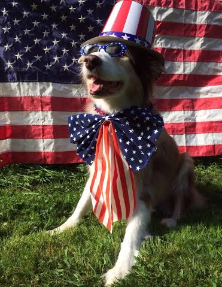

Another example, when tweets id = 716439118184652801, the rating numerator and rating denominator in the table are respectively 50 and 50. But when checking the text, it actually is: This is Bluebert. He just saw that both #FinalFur match ups are split 50/50. Amazed af. 11/10. Obviously, these two original rating numbers were wrote down wrongly, they should be 11/10.

6.Erroneous data

pupper, puppo, floofer and doggo column: There are some IDs with more than one dog stage information (two dog stages are rated).

7.Duplicated values

From coding (sum(image_prediction.jpg_url.duplicated())),we know there are some duplicated values in this column.

8.Data types are not consistent

In tweet_json table, tweet_id is object type. This is not consistent with data type in other 2 tables(int64 data type),which is not suitable for further data analysis.

9.Table size do not match

There are 2356 rows in twitter_archive, while 2075 rows in images_prediction.The size of the table do not match.

10.Timestamp accuracy

Timestamp column is object instead data time. The values in this column include year, month, day, time and number like "+0000". These numbers are mixed together. "+0000" does not make sense.

11.Dog breeds prediction consistency

The dog breeds prediction information can be found in columns p1, p1_dog, p2, p2_dog, p3 and p3_dog in image_prediction table. These value are not consistent and convenient for further analysis.

### Tidiness Issues

1 Columns issue.

One of the principle is each variable forms a column. In twitter_archive table, the last four columns all relate to the stage of dogs (dogoo, floofer, pupper, puppo). Similarly, the rating numbers are in two columns (rating_numerator and rating_denominator). This is not convenient and a little confusing. For example, most rating_numerator and rating_denominator are around 10, but some numbers are like 143/130, 121/110, or 204/170 etc.

2 Untidy data.

In twitter_archive table, column source data have <a and /a> tag in HTML format surrounding the text.These are not common internet address for ordinary users.

3 Uppercase and lowercase mixture

In images prediction table, there is no consistency in p1, p2 and p3 columns. Sometimes the dog breed predictions are lowercase, sometimes they are uppercase.

4 Many tables VS one table

Tidiness requires each type of observational unit forms a table. These three tables can be merged into one master dataset to improve data tidiness.

# Cleaning Data

```python
# Copy the datasets before cleaning
twitter_archive_clean = twitter_archive.copy()
image_prediction_clean = image_prediction.copy()
tweet_json_clean = tweet_json.copy()
```

### 1. Delete retweets

```python
twitter_archive_clean.retweeted_status_user_id.value_counts()
```

```
4.196984e+09    156
4.296832e+09      2
5.870972e+07      1
6.669901e+07      1
4.119842e+07      1
7.475543e+17      1
7.832140e+05      1
7.266347e+08      1
4.871977e+08      1
5.970642e+08      1
4.466750e+07      1
1.228326e+09      1
7.992370e+07      1
2.488557e+07      1
7.874618e+17      1
3.638908e+08      1
5.128045e+08      1
8.117408e+08      1
1.732729e+09      1
1.960740e+07      1
1.547674e+08      1
3.410211e+08      1
7.124572e+17      1
2.804798e+08      1
1.950368e+08      1
Name: retweeted_status_user_id, dtype: int64
```

```python
#Delete retweets by filtering retweeted_status_user_id
twitter_archive_clean = twitter_archive_clean[pd.isnull(twitter_archive_clean['retweeted_status_user_id'])]
```

```python
# check after deleting
twitter_archive_clean.retweeted_status_user_id.value_counts()
```

```
Series([], Name: retweeted_status_user_id, dtype: int64)
```

### 2. Clean untidy column source

```python
import re
twitter_archive_clean['source'] = twitter_archive_clean['source'].apply(lambda x: re.findall(r'>(.*)<', x)[0])
```

```python
twitter_archive_clean.head()
```

|  | tweet_id | in_reply_to_status_id | in_reply_to_user_id | timestamp | source | text | retweeted_status_id | retweeted_status_user_id | retweeted_status_timestamp | expanded_urls | rating_numerator | rating_denominator | name | doggo | floofer | pupper | puppo |
| --- | --- | --- | --- | --- | --- | --- | --- | --- | --- | --- | --- | --- | --- | --- | --- | --- | --- |
| 0 | 892420643555336193 | NaN | NaN | 2017-08-01 16:23:56 +0000 | Twitter for iPhone | This is Phineas. He's a mystical boy. Only eve... | NaN | NaN | NaN | https://twitter.com/dog_rates/status/892420643... | 13 | 10 | Phineas | None | None | None | None |
| 1 | 892177421306343426 | NaN | NaN | 2017-08-01 00:17:27 +0000 | Twitter for iPhone | This is Tilly. She's just checking pup on you.... | NaN | NaN | NaN | https://twitter.com/dog_rates/status/892177421... | 13 | 10 | Tilly | None | None | None | None |
| 2 | 891815181378084864 | NaN | NaN | 2017-07-31 00:18:03 +0000 | Twitter for iPhone | This is Archie. He is a rare Norwegian Pouncin... | NaN | NaN | NaN | https://twitter.com/dog_rates/status/891815181... | 12 | 10 | Archie | None | None | None | None |
| 3 | 891689557279858688 | NaN | NaN | 2017-07-30 15:58:51 +0000 | Twitter for iPhone | This is Darla. She commenced a snooze mid meal... | NaN | NaN | NaN | https://twitter.com/dog_rates/status/891689557... | 13 | 10 | Darla | None | None | None | None |
| 4 | 891327558926688256 | NaN | NaN | 2017-07-29 16:00:24 +0000 | Twitter for iPhone | This is Franklin. He would like you to stop ca... | NaN | NaN | NaN | https://twitter.com/dog_rates/status/891327558... | 12 | 10 | Franklin | None | None | None | None |

### 3. Delete columns that are no needed

```python
twitter_archive_clean = twitter_archive_clean.drop(['in_reply_to_user_id',
                                                    'retweeted_status_id',
                                                    'retweeted_status_user_id',
                                                    'retweeted_status_timestamp',
                                                    'expanded_urls'], axis = 1)
```

```python
# check the new table after deleting
twitter_archive_clean.head(2)
```

|  | tweet_id | in_reply_to_status_id | timestamp | source | text | rating_numerator | rating_denominator | name | doggo | floofer | pupper | puppo |
| --- | --- | --- | --- | --- | --- | --- | --- | --- | --- | --- | --- | --- |
| 0 | 892420643555336193 | NaN | 2017-08-01 16:23:56 +0000 | Twitter for iPhone | This is Phineas. He's a mystical boy. Only eve... | 13 | 10 | Phineas | None | None | None | None |
| 1 | 892177421306343426 | NaN | 2017-08-01 00:17:27 +0000 | Twitter for iPhone | This is Tilly. She's just checking pup on you.... | 13 | 10 | Tilly | None | None | None | None |

### 4. Melt columns

```python
# Extract the dog stage from the column text into the colunn
twitter_archive_clean['dog_stage'] = twitter_archive_clean['text'].str.extract('(doggo|floofer|pupper|puppo)')
```

```python
twitter_archive_clean.head(30)
```

|  | tweet_id | in_reply_to_status_id | timestamp | source | text | rating_numerator | rating_denominator | name | doggo | floofer | pupper | puppo | dog_stage |
| --- | --- | --- | --- | --- | --- | --- | --- | --- | --- | --- | --- | --- | --- |
| 0 | 892420643555336193 | NaN | 2017-08-01 16:23:56 +0000 | Twitter for iPhone | This is Phineas. He's a mystical boy. Only eve... | 13 | 10 | Phineas | None | None | None | None | NaN |
| 1 | 892177421306343426 | NaN | 2017-08-01 00:17:27 +0000 | Twitter for iPhone | This is Tilly. She's just checking pup on you.... | 13 | 10 | Tilly | None | None | None | None | NaN |
| 2 | 891815181378084864 | NaN | 2017-07-31 00:18:03 +0000 | Twitter for iPhone | This is Archie. He is a rare Norwegian Pouncin... | 12 | 10 | Archie | None | None | None | None | NaN |
| 3 | 891689557279858688 | NaN | 2017-07-30 15:58:51 +0000 | Twitter for iPhone | This is Darla. She commenced a snooze mid meal... | 13 | 10 | Darla | None | None | None | None | NaN |
| 4 | 891327558926688256 | NaN | 2017-07-29 16:00:24 +0000 | Twitter for iPhone | This is Franklin. He would like you to stop ca... | 12 | 10 | Franklin | None | None | None | None | NaN |
| 5 | 891087950875897856 | NaN | 2017-07-29 00:08:17 +0000 | Twitter for iPhone | Here we have a majestic great white breaching ... | 13 | 10 | None | None | None | None | None | NaN |
| 6 | 890971913173991426 | NaN | 2017-07-28 16:27:12 +0000 | Twitter for iPhone | Meet Jax. He enjoys ice cream so much he gets ... | 13 | 10 | Jax | None | None | None | None | NaN |
| 7 | 890729181411237888 | NaN | 2017-07-28 00:22:40 +0000 | Twitter for iPhone | When you watch your owner call another dog a g... | 13 | 10 | None | None | None | None | None | NaN |
| 8 | 890609185150312448 | NaN | 2017-07-27 16:25:51 +0000 | Twitter for iPhone | This is Zoey. She doesn't want to be one of th... | 13 | 10 | Zoey | None | None | None | None | NaN |
| 9 | 890240255349198849 | NaN | 2017-07-26 15:59:51 +0000 | Twitter for iPhone | This is Cassie. She is a college pup. Studying... | 14 | 10 | Cassie | doggo | None | None | None | doggo |
| 10 | 890006608113172480 | NaN | 2017-07-26 00:31:25 +0000 | Twitter for iPhone | This is Koda. He is a South Australian decksha... | 13 | 10 | Koda | None | None | None | None | NaN |
| 11 | 889880896479866881 | NaN | 2017-07-25 16:11:53 +0000 | Twitter for iPhone | This is Bruno. He is a service shark. Only get... | 13 | 10 | Bruno | None | None | None | None | NaN |
| 12 | 889665388333682689 | NaN | 2017-07-25 01:55:32 +0000 | Twitter for iPhone | Here's a puppo that seems to be on the fence a... | 13 | 10 | None | None | None | None | puppo | puppo |
| 13 | 889638837579907072 | NaN | 2017-07-25 00:10:02 +0000 | Twitter for iPhone | This is Ted. He does his best. Sometimes that'... | 12 | 10 | Ted | None | None | None | None | NaN |
| 14 | 889531135344209921 | NaN | 2017-07-24 17:02:04 +0000 | Twitter for iPhone | This is Stuart. He's sporting his favorite fan... | 13 | 10 | Stuart | None | None | None | puppo | puppo |
| 15 | 889278841981685760 | NaN | 2017-07-24 00:19:32 +0000 | Twitter for iPhone | This is Oliver. You're witnessing one of his m... | 13 | 10 | Oliver | None | None | None | None | NaN |
| 16 | 888917238123831296 | NaN | 2017-07-23 00:22:39 +0000 | Twitter for iPhone | This is Jim. He found a fren. Taught him how t... | 12 | 10 | Jim | None | None | None | None | NaN |
| 17 | 888804989199671297 | NaN | 2017-07-22 16:56:37 +0000 | Twitter for iPhone | This is Zeke. He has a new stick. Very proud o... | 13 | 10 | Zeke | None | None | None | None | NaN |
| 18 | 888554962724278272 | NaN | 2017-07-22 00:23:06 +0000 | Twitter for iPhone | This is Ralphus. He's powering up. Attempting ... | 13 | 10 | Ralphus | None | None | None | None | NaN |
| 20 | 888078434458587136 | NaN | 2017-07-20 16:49:33 +0000 | Twitter for iPhone | This is Gerald. He was just told he didn't get... | 12 | 10 | Gerald | None | None | None | None | NaN |
| 21 | 887705289381826560 | NaN | 2017-07-19 16:06:48 +0000 | Twitter for iPhone | This is Jeffrey. He has a monopoly on the pool... | 13 | 10 | Jeffrey | None | None | None | None | NaN |
| 22 | 887517139158093824 | NaN | 2017-07-19 03:39:09 +0000 | Twitter for iPhone | I've yet to rate a Venezuelan Hover Wiener. Th... | 14 | 10 | such | None | None | None | None | NaN |
| 23 | 887473957103951883 | NaN | 2017-07-19 00:47:34 +0000 | Twitter for iPhone | This is Canela. She attempted some fancy porch... | 13 | 10 | Canela | None | None | None | None | NaN |
| 24 | 887343217045368832 | NaN | 2017-07-18 16:08:03 +0000 | Twitter for iPhone | You may not have known you needed to see this ... | 13 | 10 | None | None | None | None | None | NaN |
| 25 | 887101392804085760 | NaN | 2017-07-18 00:07:08 +0000 | Twitter for iPhone | This... is a Jubilant Antarctic House Bear. We... | 12 | 10 | None | None | None | None | None | NaN |
| 26 | 886983233522544640 | NaN | 2017-07-17 16:17:36 +0000 | Twitter for iPhone | This is Maya. She's very shy. Rarely leaves he... | 13 | 10 | Maya | None | None | None | None | NaN |
| 27 | 886736880519319552 | NaN | 2017-07-16 23:58:41 +0000 | Twitter for iPhone | This is Mingus. He's a wonderful father to his... | 13 | 10 | Mingus | None | None | None | None | NaN |
| 28 | 886680336477933568 | NaN | 2017-07-16 20:14:00 +0000 | Twitter for iPhone | This is Derek. He's late for a dog meeting. 13... | 13 | 10 | Derek | None | None | None | None | NaN |
| 29 | 886366144734445568 | NaN | 2017-07-15 23:25:31 +0000 | Twitter for iPhone | This is Roscoe. Another pupper fallen victim t... | 12 | 10 | Roscoe | None | None | pupper | None | pupper |
| 30 | 886267009285017600 | 8.862664e+17 | 2017-07-15 16:51:35 +0000 | Twitter for iPhone | @NonWhiteHat @MayhewMayhem omg hello tanner yo... | 12 | 10 | None | None | None | None | None | NaN |

```python
#check the column after changing
twitter_archive_clean.dog_stage.value_counts()
```

```
pupper     244
doggo       84
puppo       32
floofer      4
Name: dog_stage, dtype: int64
```

```python
# drop the 4 original columns
twitter_archive_clean = twitter_archive_clean.drop(['doggo','floofer','puppo','pupper'],axis=1)
```

```python
# check after correction
twitter_archive_clean.head(2)
```

|  | tweet_id | in_reply_to_status_id | timestamp | source | text | rating_numerator | rating_denominator | name | dog_stage |
| --- | --- | --- | --- | --- | --- | --- | --- | --- | --- |
| 0 | 892420643555336193 | NaN | 2017-08-01 16:23:56 +0000 | Twitter for iPhone | This is Phineas. He's a mystical boy. Only eve... | 13 | 10 | Phineas | NaN |
| 1 | 892177421306343426 | NaN | 2017-08-01 00:17:27 +0000 | Twitter for iPhone | This is Tilly. She's just checking pup on you.... | 13 | 10 | Tilly | NaN |

### 5. Adjust timestamp data

```python
#convert timestamp to datetime
twitter_archive_clean['timestamp'] = pd.to_datetime(twitter_archive_clean['timestamp'])
```

```python
# put time data to new columns
twitter_archive_clean['year'] = twitter_archive_clean['timestamp'].dt.year
twitter_archive_clean['month'] = twitter_archive_clean['timestamp'].dt.month
twitter_archive_clean['day'] = twitter_archive_clean['timestamp'].dt.day
```

```python
#drop the original timestamp column
twitter_archive_clean = twitter_archive_clean.drop(['timestamp'],axis = 1)
```

```python
# check twitter_archive after cleaning
twitter_archive_clean.head(2)
```

|  | tweet_id | in_reply_to_status_id | source | text | rating_numerator | rating_denominator | name | dog_stage | year | month | day |
| --- | --- | --- | --- | --- | --- | --- | --- | --- | --- | --- | --- |
| 0 | 892420643555336193 | NaN | Twitter for iPhone | This is Phineas. He's a mystical boy. Only eve... | 13 | 10 | Phineas | NaN | 2017 | 8 | 1 |
| 1 | 892177421306343426 | NaN | Twitter for iPhone | This is Tilly. She's just checking pup on you.... | 13 | 10 | Tilly | NaN | 2017 | 8 | 1 |

### 6. Correct dog name

```python
twitter_archive_clean.name.value_counts()
```

```
None          680
a              55
Lucy           11
Charlie        11
Cooper         10
Oliver         10
Tucker          9
Penny           9
Lola            8
Winston         8
Sadie           8
the             8
Toby            7
Daisy           7
Oscar           6
Bo              6
Jax             6
Koda            6
Bella           6
an              6
Stanley         6
Bailey          6
Rusty           5
Buddy           5
Chester         5
Bentley         5
Milo            5
Leo             5
Louis           5
Scout           5
             ...
Pancake         1
Jangle          1
Tuck            1
Traviss         1
Brady           1
Aja             1
Snickers        1
Franq           1
Mairi           1
Gin             1
Alf             1
Rilo            1
Bradlay         1
Kellogg         1
Kulet           1
Cupid           1
Leonard         1
Teddy           1
Creg            1
Opie            1
Smiley          1
Ziva            1
Paull           1
Christoper      1
Monkey          1
Tanner          1
Vixen           1
Skittle         1
Barry           1
Donny           1
Name: name, Length: 956, dtype: int64
```

Replace "a" and "an" with "None" in column name

```python
twitter_archive_clean.name = twitter_archive_clean.name.str.replace('a', 'None')
```

```python
twitter_archive_clean.name = twitter_archive_clean.name.str.replace('an', 'None')
```

```python
# check table after replacement
twitter_archive_clean.loc[twitter_archive_clean.name == 'an']
```

|  | tweet_id | in_reply_to_status_id | source | text | rating_numerator | rating_denominator | name | dog_stage | year | month | day |
| --- | --- | --- | --- | --- | --- | --- | --- | --- | --- | --- | --- |

```python
# check table after replacement
twitter_archive_clean.loc[twitter_archive_clean.name == 'a']
```

|  | tweet_id | in_reply_to_status_id | source | text | rating_numerator | rating_denominator | name | dog_stage | year | month | day |
| --- | --- | --- | --- | --- | --- | --- | --- | --- | --- | --- | --- |

### 7. Correct rating data

```python
# Change the data type to facilitate further analysis
twitter_archive_clean[['rating_numerator', 'rating_denominator']] = twitter_archive_clean[['rating_numerator','rating_denominator']].astype(float)
```

```python
twitter_archive_clean.rating_numerator.value_counts()
```

```
12.0      500
10.0      442
11.0      426
13.0      307
9.0       156
8.0        98
7.0        54
14.0       43
5.0        36
6.0        32
3.0        19
4.0        17
2.0         9
1.0         8
0.0         2
420.0       2
84.0        1
24.0        1
27.0        1
15.0        1
17.0        1
960.0       1
143.0       1
99.0        1
666.0       1
121.0       1
182.0       1
165.0       1
45.0        1
75.0        1
204.0       1
1776.0      1
80.0        1
88.0        1
144.0       1
26.0        1
20.0        1
44.0        1
60.0        1
50.0        1
Name: rating_numerator, dtype: int64
```

```python
# check the texts of some outliers to see if the numbers are right or not
twitter_archive_clean.query("rating_numerator < 5").loc[:,['text','rating_numerator']]
```

|  | text | rating_numerator |
| --- | --- | --- |
| 315 | When you're so blinded by your systematic plag... | 0.0 |
| 765 | This is Wesley. He's clearly trespassing. Seem... | 3.0 |
| 883 | This is Fido. He can tell the weather. Not goo... | 4.0 |
| 912 | Here's another picture without a dog in it. Id... | 4.0 |
| 1004 | Viewer discretion is advised. This is a terrib... | 4.0 |
| 1016 | PUPDATE: can't see any. Even if I could, I cou... | 0.0 |
| 1165 | Happy 4/20 from the squad! 13/10 for all https... | 4.0 |
| 1189 | This is Alexanderson. He's got a weird ass bir... | 3.0 |
| 1219 | This is Benedict. He's a feisty pup. Needs a b... | 4.0 |
| 1249 | What hooligan sent in pictures w/out a dog in ... | 3.0 |
| 1303 | This is Keurig. He's a rare dog. Laughs like a... | 4.0 |
| 1314 | This is Elliot. He's blocking the roadway. Dow... | 3.0 |
| 1406 | This is Charl. He's a bully. Chucks that dumbb... | 3.0 |
| 1446 | After reading the comments I may have overesti... | 1.0 |
| 1459 | This may be the greatest video I've ever been ... | 4.0 |
| 1478 | Meet Phil. He's big af. Currently destroying t... | 3.0 |
| 1598 | Yes I do realize a rating of 4/20 would've bee... | 4.0 |
| 1601 | This is Hammond. He's a peculiar pup. Loves lo... | 3.0 |
| 1629 | This is Bobby. He doesn't give a damn about pe... | 4.0 |
| 1692 | This is Chuck. He's a neat dog. Very flexible.... | 3.0 |
| 1701 | This is Alice. She's an idiot. 4/10 https://t.... | 4.0 |
| 1761 | Exotic pup here. Tail long af. Throat looks sw... | 2.0 |
| 1764 | This is Crystal. She's a shitty fireman. No se... | 2.0 |
| 1836 | Extremely rare pup here. Very religious. Alway... | 3.0 |
| 1869 | What kind of person sends in a picture without... | 1.0 |
| 1898 | Meet Patrick. He's an exotic pup. Jumps great ... | 3.0 |
| 1920 | This is Henry. He's a shit dog. Short pointy e... | 2.0 |
| 1928 | Herd of wild dogs here. Not sure what they're ... | 3.0 |
| 1938 | Guys I'm getting real tired of this. We only r... | 3.0 |
| 1940 | The millennials have spoken and we've decided ... | 1.0 |
| 1941 | This is a heavily opinionated dog. Loves walls... | 4.0 |
| 1947 | Large blue dog here. Cool shades. Flipping us ... | 3.0 |
| 2038 | After 22 minutes of careful deliberation this ... | 1.0 |
| 2070 | Two miniature golden retrievers here. Webbed p... | 4.0 |
| 2076 | Pink dogs here. Unreasonably long necks. Left ... | 4.0 |
| 2079 | Scary dog here. Too many legs. Extra tail. Not... | 2.0 |
| 2091 | Flamboyant pup here. Probably poisonous. Won't... | 1.0 |
| 2136 | This is Tommy. He's a cool dog. Hard not to st... | 3.0 |
| 2183 | This is Bernie. He's taking his Halloween cost... | 3.0 |
| 2186 | Unique dog here. Oddly shaped tail. Long pink ... | 4.0 |
| 2202 | Fascinating dog here. Loves beach. Oddly long ... | 3.0 |
| 2222 | Here is a mother dog caring for her pups. Snaz... | 4.0 |
| 2237 | This lil pup is Oliver. Hops around. Has wings... | 2.0 |
| 2239 | This dog resembles a baked potato. Bed looks u... | 3.0 |
| 2246 | This is Tedrick. He lives on the edge. Needs s... | 2.0 |
| 2261 | Never seen dog like this. Breathes heavy. Tilt... | 1.0 |
| 2288 | These are strange dogs. All have toupees. Long... | 4.0 |
| 2305 | My goodness. Very rare dog here. Large. Tail d... | 3.0 |
| 2310 | Unfamiliar with this breed. Ears pointy af. Wo... | 2.0 |
| 2316 | Cool dog. Enjoys couch. Low monotone bark. Ver... | 4.0 |
| 2326 | This is quite the dog. Gets really excited whe... | 2.0 |
| 2334 | This is a funny dog. Weird toes. Won't come do... | 3.0 |
| 2335 | This is an Albanian 3 1/2 legged Episcopalian... | 1.0 |
| 2338 | Not familiar with this breed. No tail (weird).... | 1.0 |
| 2349 | This is an odd dog. Hard on the outside but lo... | 2.0 |

```python
# The visual window is too small to show all sentences
# I opened the table in Excel to see the complete texts
twitter_archive_clean.loc[(1165,1459,2335),['text','rating_numerator']]
```

|  | text | rating_numerator |
| --- | --- | --- |
| 1165 | Happy 4/20 from the squad! 13/10 for all https... | 4.0 |
| 1459 | This may be the greatest video I've ever been ... | 4.0 |
| 2335 | This is an Albanian 3 1/2 legged Episcopalian... | 1.0 |

```python
# The texts shows these rating_numerator are not right and should be corrected
twitter_archive_clean.loc[2335,'rating_numerator'] = 9
twitter_archive_clean.loc[(1165,1459),'rating_numerator'] = 13
```

```python
# check after correction
twitter_archive_clean.loc[(1165,1459,2335),['text','rating_numerator']]
```

|  | text | rating_numerator |
| --- | --- | --- |
| 1165 | Happy 4/20 from the squad! 13/10 for all https... | 13.0 |
| 1459 | This may be the greatest video I've ever been ... | 13.0 |
| 2335 | This is an Albanian 3 1/2 legged Episcopalian... | 9.0 |

```python
# Then we check the rating_denominators
twitter_archive_clean.rating_denominator.value_counts()
```

```
10.0     2153
50.0        3
11.0        2
20.0        2
80.0        2
110.0       1
0.0         1
15.0        1
7.0         1
150.0       1
16.0        1
120.0       1
2.0         1
170.0       1
70.0        1
130.0       1
90.0        1
40.0        1
Name: rating_denominator, dtype: int64
```

```python
# Usually, rating_denominators are 10,
# assessing the texts when rating_denominator are not 10

twitter_archive_clean.query("rating_denominator != 10").loc[:,['tweet_id','text','rating_denominator']]
```

|  | tweet_id | text | rating_denominator |
| --- | --- | --- | --- |
| 313 | 835246439529840640 | @jonnysun @Lin_Manuel ok jomny I know you're e... | 0.0 |
| 342 | 832088576586297345 | @docmisterio account started on 11/15/15 | 15.0 |
| 433 | 820690176645140481 | The floofs have been released I repeat the flo... | 70.0 |
| 516 | 810984652412424192 | Meet Sam. She smiles 24/7 &amp; secretly aspir... | 7.0 |
| 902 | 758467244762497024 | Why does this never happen at my front door...... | 150.0 |
| 1068 | 740373189193256964 | After so many requests, this is Bretagne. She ... | 11.0 |
| 1120 | 731156023742988288 | Say hello to this unbelievably well behaved sq... | 170.0 |
| 1165 | 722974582966214656 | Happy 4/20 from the squad! 13/10 for all https... | 20.0 |
| 1202 | 716439118184652801 | This is Bluebert. He just saw that both #Final... | 50.0 |
| 1228 | 713900603437621249 | Happy Saturday here's 9 puppers on a bench. 99... | 90.0 |
| 1254 | 710658690886586372 | Here's a brigade of puppers. All look very pre... | 80.0 |
| 1274 | 709198395643068416 | From left to right:\nCletus, Jerome, Alejandro... | 50.0 |
| 1351 | 704054845121142784 | Here is a whole flock of puppers. 60/50 I'll ... | 50.0 |
| 1433 | 697463031882764288 | Happy Wednesday here's a bucket of pups. 44/40... | 40.0 |
| 1598 | 686035780142297088 | Yes I do realize a rating of 4/20 would've bee... | 20.0 |
| 1634 | 684225744407494656 | Two sneaky puppers were not initially seen, mo... | 130.0 |
| 1635 | 684222868335505415 | Someone help the girl is being mugged. Several... | 110.0 |
| 1662 | 682962037429899265 | This is Darrel. He just robbed a 7/11 and is i... | 11.0 |
| 1663 | 682808988178739200 | I'm aware that I could've said 20/16, but here... | 16.0 |
| 1779 | 677716515794329600 | IT'S PUPPERGEDDON. Total of 144/120 ...I think... | 120.0 |
| 1843 | 675853064436391936 | Here we have an entire platoon of puppers. Tot... | 80.0 |
| 2335 | 666287406224695296 | This is an Albanian 3 1/2 legged Episcopalian... | 2.0 |

```python
# After downloading locally and checking the full texts in Excel
# Replace some of the rating_denominators with 10 if the texts show the real meaning
# Replace the related rating numerators if they are also wrong
twitter_archive_clean.rating_denominator[twitter_archive_clean.tweet_id == 740373189193256964] = 10
twitter_archive_clean.rating_numerator[twitter_archive_clean.tweet_id == 740373189193256964] = 14
#
twitter_archive_clean.rating_denominator[twitter_archive_clean.tweet_id == 722974582966214656] = 10
twitter_archive_clean.rating_numerator[twitter_archive_clean.tweet_id == 722974582966214656] = 13
#
twitter_archive_clean.rating_denominator[twitter_archive_clean.tweet_id == 716439118184652801] = 10
twitter_archive_clean.rating_numerator[twitter_archive_clean.tweet_id == 716439118184652801] = 11
#
twitter_archive_clean.rating_denominator[twitter_archive_clean.tweet_id == 682962037429899265] = 10
twitter_archive_clean.rating_numerator[twitter_archive_clean.tweet_id == 682962037429899265] = 10
#
twitter_archive_clean.rating_denominator[twitter_archive_clean.tweet_id == 666287406224695296] = 10
twitter_archive_clean.rating_numerator[twitter_archive_clean.tweet_id == 666287406224695296] = 9
```

[output not shown]

```python
# the highest rating numerator is 1776 (the year when US became independent)
twitter_archive_clean.rating_numerator[twitter_archive_clean.tweet_id == 749981277374128128]
```

```
979    1776.0
Name: rating_numerator, dtype: float64
```

```python
# replace it with 10
twitter_archive_clean.rating_numerator[twitter_archive_clean.tweet_id == 749981277374128128] = 10
```

```python
# check after replacement
twitter_archive_clean.loc[[1068, 1165,1202,1662,2335]]
```

|  | tweet_id | in_reply_to_status_id | source | text | rating_numerator | rating_denominator | name | dog_stage | year | month | day |
| --- | --- | --- | --- | --- | --- | --- | --- | --- | --- | --- | --- |
| 1068 | 740373189193256964 | NaN | Twitter for iPhone | After so many requests, this is Bretagne. She ... | 14.0 | 10.0 | None | NaN | 2016 | 6 | 8 |
| 1165 | 722974582966214656 | NaN | Twitter for iPhone | Happy 4/20 from the squad! 13/10 for all https... | 13.0 | 10.0 | None | NaN | 2016 | 4 | 21 |
| 1202 | 716439118184652801 | NaN | Twitter for iPhone | This is Bluebert. He just saw that both #Final... | 11.0 | 10.0 | Bluebert | NaN | 2016 | 4 | 3 |
| 1662 | 682962037429899265 | NaN | Twitter for iPhone | This is Darrel. He just robbed a 7/11 and is i... | 10.0 | 10.0 | DNonerrel | NaN | 2016 | 1 | 1 |
| 2335 | 666287406224695296 | NaN | Twitter for iPhone | This is an Albanian 3 1/2 legged Episcopalian... | 9.0 | 10.0 | Nonen | NaN | 2015 | 11 | 16 |

```python
# check after replacement
twitter_archive_clean.rating_numerator[twitter_archive_clean.tweet_id == 749981277374128128]
```

```
979    10.0
Name: rating_numerator, dtype: float64
```

```python
# Since there are still som rating_denominators are not 10
# It is hard to compare rating_numerators directly
# Create a new column with rating in float type to compare dogs' rating scores
twitter_archive_clean['rating'] = 10 * twitter_archive_clean['rating_numerator'] / twitter_archive_clean['rating_denominator'].astype(float)

twitter_archive_clean.head()
```

|  | tweet_id | in_reply_to_status_id | source | text | rating_numerator | rating_denominator | name | dog_stage | year | month | day | rating |
| --- | --- | --- | --- | --- | --- | --- | --- | --- | --- | --- | --- | --- |
| 0 | 892420643555336193 | NaN | Twitter for iPhone | This is Phineas. He's a mystical boy. Only eve... | 13.0 | 10.0 | PhineNones | NaN | 2017 | 8 | 1 | 13.0 |
| 1 | 892177421306343426 | NaN | Twitter for iPhone | This is Tilly. She's just checking pup on you.... | 13.0 | 10.0 | Tilly | NaN | 2017 | 8 | 1 | 13.0 |
| 2 | 891815181378084864 | NaN | Twitter for iPhone | This is Archie. He is a rare Norwegian Pouncin... | 12.0 | 10.0 | Archie | NaN | 2017 | 7 | 31 | 12.0 |
| 3 | 891689557279858688 | NaN | Twitter for iPhone | This is Darla. She commenced a snooze mid meal... | 13.0 | 10.0 | DNonerlNone | NaN | 2017 | 7 | 30 | 13.0 |
| 4 | 891327558926688256 | NaN | Twitter for iPhone | This is Franklin. He would like you to stop ca... | 12.0 | 10.0 | FrNonenklin | NaN | 2017 | 7 | 29 | 12.0 |

### 8. Delete duplicated jpg_urls

```python
#Delete 66 duplicated jpg_url
image_prediction_clean = image_prediction_clean.drop_duplicates(subset=['jpg_url'], keep='last')
```

```python
# Check after deletilng
sum(image_prediction_clean['jpg_url'].duplicated())
```

```
0
```

```python
#Check the table
image_prediction_clean.head()
```

|  | tweet_id | jpg_url | img_num | p1 | p1_conf | p1_dog | p2 | p2_conf | p2_dog | p3 | p3_conf | p3_dog |
| --- | --- | --- | --- | --- | --- | --- | --- | --- | --- | --- | --- | --- |
| 0 | 666020888022790149 | https://pbs.twimg.com/media/CT4udn0WwAA0aMy.jpg | 1 | Welsh_springer_spaniel | 0.465074 | True | collie | 0.156665 | True | Shetland_sheepdog | 0.061428 | True |
| 1 | 666029285002620928 | https://pbs.twimg.com/media/CT42GRgUYAA5iDo.jpg | 1 | redbone | 0.506826 | True | miniature_pinscher | 0.074192 | True | Rhodesian_ridgeback | 0.072010 | True |
| 2 | 666033412701032449 | https://pbs.twimg.com/media/CT4521TWwAEvMyu.jpg | 1 | German_shepherd | 0.596461 | True | malinois | 0.138584 | True | bloodhound | 0.116197 | True |
| 3 | 666044226329800704 | https://pbs.twimg.com/media/CT5Dr8HUEAA-lEu.jpg | 1 | Rhodesian_ridgeback | 0.408143 | True | redbone | 0.360687 | True | miniature_pinscher | 0.222752 | True |
| 4 | 666049248165822465 | https://pbs.twimg.com/media/CT5IQmsXIAAKY4A.jpg | 1 | miniature_pinscher | 0.560311 | True | Rottweiler | 0.243682 | True | Doberman | 0.154629 | True |

### 8. Change tweet_id data type

```python
tweet_json_clean['tweet_id'] = tweet_json_clean['tweet_id'].astype(int)
```

```python
tweet_json_clean['tweet_id'].dtypes
```

```
dtype('int64')
```

### 9. Dog breeds prediction

```python
# I get the dog breed prediction data from p1, p2 or p3

dog_breed = []

def image(image_prediction_clean):
    if image_prediction_clean['p1_dog'] == True:
        dog_breed.append(image_prediction_clean['p1'])

    elif image_prediction_clean['p2_dog'] == True:
        dog_breed.append(image_prediction_clean['p2'])

    elif image_prediction_clean['p3_dog'] == True:
        dog_breed.append(image_prediction_clean['p3'])

    else:
        dog_breed.append('False')

image_prediction_clean.apply(image, axis=1)

image_prediction_clean['dog_breed'] = dog_breed
```

```python
#drop rows that has false prediction
image_prediction_clean = image_prediction_clean[image_prediction_clean['dog_breed'] != 'False']

image_prediction_clean.info()
```

```
<class 'pandas.core.frame.DataFrame'>
Int64Index: 1691 entries, 0 to 2073
Data columns (total 13 columns):
tweet_id     1691 non-null int64
jpg_url      1691 non-null object
img_num      1691 non-null int64
p1           1691 non-null object
p1_conf      1691 non-null float64
p1_dog       1691 non-null bool
p2           1691 non-null object
p2_conf      1691 non-null float64
p2_dog       1691 non-null bool
p3           1691 non-null object
p3_conf      1691 non-null float64
p3_dog       1691 non-null bool
dog_breed    1691 non-null object
dtypes: bool(3), float64(3), int64(2), object(5)
memory usage: 150.3+ KB
```

### 10. Merge these into one master dataframe

```python
#Firstly, merge twitter_archive_clean and image_prediction_clean
df_twitter_transition = pd.merge(twitter_archive_clean,
                      image_prediction_clean,
                      how = 'left', on = ['tweet_id'])

#keep rows that have picture (jpg_url)
df_twitter_transition = df_twitter_transition[df_twitter_transition['jpg_url'].notnull()]
```

```python
#Secondly, merge df_twitter1 and tweet_json_clean
df_twitter = pd.merge(df_twitter_transition, tweet_json_clean,
                      how = 'left', on = ['tweet_id'])

df_twitter.info()
```

```
<class 'pandas.core.frame.DataFrame'>
Int64Index: 1626 entries, 0 to 1625
Data columns (total 28 columns):
tweet_id                 1626 non-null int64
in_reply_to_status_id    20 non-null float64
source                   1626 non-null object
text                     1626 non-null object
rating_numerator         1626 non-null float64
rating_denominator       1626 non-null float64
name                     1626 non-null object
dog_stage                266 non-null object
year                     1626 non-null int64
month                    1626 non-null int64
day                      1626 non-null int64
rating                   1626 non-null float64
jpg_url                  1626 non-null object
img_num                  1626 non-null float64
p1                       1626 non-null object
p1_conf                  1626 non-null float64
p1_dog                   1626 non-null object
p2                       1626 non-null object
p2_conf                  1626 non-null float64
p2_dog                   1626 non-null object
p3                       1626 non-null object
p3_conf                  1626 non-null float64
p3_dog                   1626 non-null object
dog_breed                1626 non-null object
favorite_count           1620 non-null float64
retweet_count            1620 non-null float64
followers_count          1620 non-null float64
friends_count            1620 non-null float64
dtypes: float64(12), int64(4), object(12)
memory usage: 368.4+ KB
```

## Storing, Analyzing, and Visualizing Data

```python
#Store the master DataFrame
df_twitter.to_csv('twitter_archive_master.csv',encoding = 'utf-8',index=False)
```

```python
df_twitter.head()
```

|  | tweet_id | in_reply_to_status_id | source | text | rating_numerator | rating_denominator | name | dog_stage | year | month | ... | p2_conf | p2_dog | p3 | p3_conf | p3_dog | dog_breed | favorite_count | retweet_count | followers_count | friends_count |
| --- | --- | --- | --- | --- | --- | --- | --- | --- | --- | --- | --- | --- | --- | --- | --- | --- | --- | --- | --- | --- | --- |
| 0 | 892177421306343426 | NaN | Twitter for iPhone | This is Tilly. She's just checking pup on you.... | 13.0 | 10.0 | Tilly | NaN | 2017 | 8 | ... | 0.090647 | True | papillon | 0.068957 | True | Chihuahua | 31090.0 | 5674.0 | 8781558.0 | 16.0 |
| 1 | 891815181378084864 | NaN | Twitter for iPhone | This is Archie. He is a rare Norwegian Pouncin... | 12.0 | 10.0 | Archie | NaN | 2017 | 7 | ... | 0.078253 | True | kelpie | 0.031379 | True | Chihuahua | 23398.0 | 3761.0 | 8781558.0 | 16.0 |
| 2 | 891689557279858688 | NaN | Twitter for iPhone | This is Darla. She commenced a snooze mid meal... | 13.0 | 10.0 | DNonerlNone | NaN | 2017 | 7 | ... | 0.168086 | True | spatula | 0.040836 | False | Labrador_retriever | 39316.0 | 7848.0 | 8781558.0 | 16.0 |
| 3 | 891327558926688256 | NaN | Twitter for iPhone | This is Franklin. He would like you to stop ca... | 12.0 | 10.0 | FrNonenklin | NaN | 2017 | 7 | ... | 0.225770 | True | German_short-haired_pointer | 0.175219 | True | basset | 37552.0 | 8446.0 | 8781558.0 | 16.0 |
| 4 | 891087950875897856 | NaN | Twitter for iPhone | Here we have a majestic great white breaching ... | 13.0 | 10.0 | None | NaN | 2017 | 7 | ... | 0.116317 | True | Indian_elephant | 0.076902 | False | Chesapeake_Bay_retriever | 18923.0 | 2833.0 | 8781558.0 | 16.0 |

5 rows × 28 columns

### 1.The most common dog breed

```python
df_twitter['dog_breed'].value_counts()
```

```
golden_retriever                  143
Labrador_retriever                103
Pembroke                           94
Chihuahua                          87
pug                                60
toy_poodle                         50
chow                               45
Pomeranian                         42
Samoyed                            38
malamute                           32
Chesapeake_Bay_retriever           31
French_bulldog                     30
cocker_spaniel                     26
miniature_pinscher                 24
Eskimo_dog                         22
German_shepherd                    21
Siberian_husky                     20
Shih-Tzu                           20
Staffordshire_bullterrier          20
Cardigan                           19
Shetland_sheepdog                  19
beagle                             19
Maltese_dog                        19
Rottweiler                         19
kuvasz                             18
Lakeland_terrier                   17
Italian_greyhound                  17
basset                             17
American_Staffordshire_terrier     16
West_Highland_white_terrier        16
                                 ...
Rhodesian_ridgeback                 4
Gordon_setter                       4
giant_schnauzer                     4
Saluki                              4
Leonberg                            3
curly-coated_retriever              3
toy_terrier                         3
komondor                            3
Greater_Swiss_Mountain_dog          3
cairn                               3
Irish_water_spaniel                 3
Irish_setter                        3
Brabancon_griffon                   3
briard                              3
Tibetan_mastiff                     3
Sussex_spaniel                      2
black-and-tan_coonhound             2
groenendael                         2
Afghan_hound                        2
Appenzeller                         2
wire-haired_fox_terrier             2
Australian_terrier                  2
EntleBucher                         1
clumber                             1
Irish_wolfhound                     1
Japanese_spaniel                    1
silky_terrier                       1
Bouvier_des_Flandres                1
standard_schnauzer                  1
Scotch_terrier                      1
Name: dog_breed, Length: 113, dtype: int64
```

```
Text(0.5,1,'The Most common Dog Breed')
```

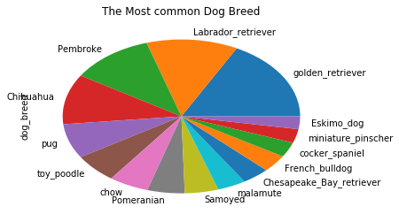

```python
# Visualization of the most common dog breed
# We choose the first 15 dog breeds and dropping other unimportant dog types
df_twitter['dog_breed'].value_counts()[0:15].plot(kind = 'pie')
plt.title('The Most common Dog Breed')
```

#### Insight 1.

#### Obviously, golden_retriever is the most common dog breed. The second breed is labrador retriever. The third is pembroke. The forth is chihuahua. Although, there are altogether 113 dog breeds in the data frame, these four dog types consist of about half of the first 15 dog breeds. This finding might be a very useful sample for related pet industry. It tells which breeds are popular and which breeds are rare.

### 2. The highest rating dog breed

```python
df_dog_breed_mean = df_twitter.groupby('dog_breed').mean()
```

```python
df_dog_breed_mean.head(10)
```

| dog_breed | tweet_id | in_reply_to_status_id | rating_numerator | rating_denominator | year | month | day | rating | img_num | p1_conf | p2_conf | p3_conf | favorite_count | retweet_count | followers_count | friends_count |
| --- | --- | --- | --- | --- | --- | --- | --- | --- | --- | --- | --- | --- | --- | --- | --- | --- |
| Afghan_hound | 8.095999e+17 | NaN | 8.000000 | 10.0 | 2016.500000 | 6.000000 | 16.000000 | 8.000000 | 1.000000 | 0.513621 | 0.077449 | 0.067637 | 11063.000000 | 3128.000000 | 8.781562e+06 | 16.0 |
| Airedale | 7.184489e+17 | NaN | 9.833333 | 10.0 | 2015.583333 | 8.750000 | 15.916667 | 9.833333 | 1.166667 | 0.583771 | 0.129887 | 0.083516 | 4802.916667 | 1219.916667 | 8.781611e+06 | 16.0 |
| American_Staffordshire_terrier | 7.597284e+17 | NaN | 10.312500 | 10.0 | 2016.187500 | 5.250000 | 15.000000 | 10.312500 | 1.187500 | 0.641898 | 0.146242 | 0.052138 | 7689.666667 | 1800.533333 | 8.781593e+06 | 16.0 |
| Appenzeller | 7.939334e+17 | NaN | 11.000000 | 10.0 | 2016.500000 | 4.500000 | 18.500000 | 11.000000 | 1.000000 | 0.503665 | 0.152041 | 0.130708 | 6662.500000 | 1258.500000 | 8.781582e+06 | 16.0 |
| Australian_terrier | 7.785921e+17 | NaN | 11.500000 | 10.0 | 2016.500000 | 3.500000 | 7.000000 | 11.500000 | 2.000000 | 0.307584 | 0.242234 | 0.115970 | 10149.000000 | 2726.000000 | 8.781585e+06 | 16.0 |
| Bedlington_terrier | 7.843395e+17 | NaN | 10.333333 | 10.0 | 2016.333333 | 6.000000 | 7.333333 | 10.333333 | 1.000000 | 0.438402 | 0.140861 | 0.091291 | 22895.833333 | 7281.166667 | 8.781585e+06 | 16.0 |
| Bernese_mountain_dog | 7.570201e+17 | NaN | 11.272727 | 10.0 | 2016.090909 | 6.090909 | 17.727273 | 11.272727 | 1.181818 | 0.767392 | 0.139979 | 0.033447 | 6650.363636 | 1412.545455 | 8.781591e+06 | 16.0 |
| Blenheim_spaniel | 7.404407e+17 | NaN | 11.100000 | 10.0 | 2015.800000 | 8.200000 | 13.900000 | 11.100000 | 1.400000 | 0.699588 | 0.093572 | 0.043319 | 8439.600000 | 2254.800000 | 8.781602e+06 | 16.0 |
| Border_collie | 7.457945e+17 | NaN | 10.583333 | 10.0 | 2016.083333 | 5.250000 | 14.666667 | 10.583333 | 1.416667 | 0.576845 | 0.190686 | 0.077855 | 8168.083333 | 1946.333333 | 8.781599e+06 | 16.0 |
| Border_terrier | 7.933788e+17 | NaN | 12.142857 | 10.0 | 2016.714286 | 2.000000 | 14.428571 | 12.142857 | 1.000000 | 0.464345 | 0.182590 | 0.079216 | 12411.000000 | 2972.428571 | 8.781575e+06 | 16.0 |

```python
df_dog_breed_sorted = df_dog_breed_mean['rating'].sort_values()

df_dog_breed_sorted
```

```
dog_breed
Japanese_spaniel                5.000000
Afghan_hound                    8.000000
soft-coated_wheaten_terrier     8.800000
Walker_hound                    9.000000
Scotch_terrier                  9.000000
Tibetan_terrier                 9.250000
dalmatian                       9.272727
Boston_bull                     9.416667
Saint_Bernard                   9.500000
Welsh_springer_spaniel          9.500000
Dandie_Dinmont                  9.571429
Norwich_terrier                 9.600000
miniature_schnauzer             9.600000
redbone                         9.666667
English_setter                  9.714286
Maltese_dog                     9.736842
Rhodesian_ridgeback             9.750000
Scottish_deerhound              9.750000
Irish_terrier                   9.800000
Airedale                        9.833333
papillon                        9.833333
Newfoundland                    9.857143
Mexican_hairless                9.857143
miniature_poodle                9.875000
miniature_pinscher              9.916667
Brabancon_griffon              10.000000
Italian_greyhound              10.000000
groenendael                    10.000000
Ibizan_hound                   10.000000
beagle                         10.052632
                                 ...
Labrador_retriever             11.194175
Bernese_mountain_dog           11.272727
Siberian_husky                 11.300000
kelpie                         11.307692
Doberman                       11.333333
Leonberg                       11.333333
Greater_Swiss_Mountain_dog     11.333333
Irish_water_spaniel            11.333333
```

[output cut: 8 more lines]

```
kuvasz                         11.611111
Samoyed                        11.657895
golden_retriever               11.687313
Gordon_setter                  11.750000
standard_schnauzer             12.000000
silky_terrier                  12.000000
Tibetan_mastiff                12.000000
Border_terrier                 12.142857
Irish_setter                   12.333333
briard                         12.333333
Pomeranian                     12.476190
Saluki                         12.500000
Bouvier_des_Flandres           13.000000
clumber                        27.000000
Name: rating, Length: 113, dtype: float64
```

```python
# choosing the rating higher than 11.5 in order to simplify the visualization
df_highratings = df_dog_breed_mean[df_dog_breed_mean.rating >= 11.5]
```

```
Text(0.5,1,'The Highest Rating Dog Breed')
```

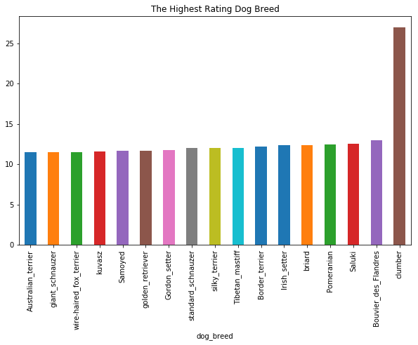

```python
df_highratings['rating'].sort_values().plot(kind = "bar", figsize = (10,6))
plt.title("The Highest Rating Dog Breed")
```

```python
# The clumber dog breed has the highest rating
# check this extreme value and found this clumber dog only has one sample
df_twitter.loc[df_twitter.dog_breed == "clumber"]
```

|  | tweet_id | in_reply_to_status_id | source | text | rating_numerator | rating_denominator | name | dog_stage | year | month | ... | p2_conf | p2_dog | p3 | p3_conf | p3_dog | dog_breed | favorite_count | retweet_count | followers_count | friends_count |
| --- | --- | --- | --- | --- | --- | --- | --- | --- | --- | --- | --- | --- | --- | --- | --- | --- | --- | --- | --- | --- | --- |
| 469 | 778027034220126208 | NaN | Twitter for iPhone | This is Sophie. She's a Jubilant Bush Pupper. ... | 27.0 | 10.0 | Sophie | NaN | 2016 | 9 | ... | 0.01595 | True | Lhasa | 0.006519 | True | clumber | 6609.0 | 1633.0 | 8781562.0 | 16.0 |

1 rows × 28 columns

```python
# Drop this outlier row
df_twitter = df_twitter.drop(df_twitter[df_twitter.dog_breed == "clumber"].index)
```

```python
# check after deleting
df_twitter.loc[df_twitter.dog_breed == "clumber"]
```

|  | tweet_id | in_reply_to_status_id | source | text | rating_numerator | rating_denominator | name | dog_stage | year | month | ... | p2_conf | p2_dog | p3 | p3_conf | p3_dog | dog_breed | favorite_count | retweet_count | followers_count | friends_count |
| --- | --- | --- | --- | --- | --- | --- | --- | --- | --- | --- | --- | --- | --- | --- | --- | --- | --- | --- | --- | --- | --- |

0 rows × 28 columns

```python
df_dog_breed_mean = df_twitter.groupby('dog_breed').mean()
```

```python
df_dog_breed_sorted = df_dog_breed_mean['rating'].sort_values()

df_dog_breed_sorted
```

```
dog_breed
Japanese_spaniel                5.000000
Afghan_hound                    8.000000
soft-coated_wheaten_terrier     8.800000
Scotch_terrier                  9.000000
Walker_hound                    9.000000
Tibetan_terrier                 9.250000
dalmatian                       9.272727
Boston_bull                     9.416667
Saint_Bernard                   9.500000
Welsh_springer_spaniel          9.500000
Dandie_Dinmont                  9.571429
miniature_schnauzer             9.600000
Norwich_terrier                 9.600000
redbone                         9.666667
English_setter                  9.714286
Maltese_dog                     9.736842
Rhodesian_ridgeback             9.750000
Scottish_deerhound              9.750000
Irish_terrier                   9.800000
papillon                        9.833333
Airedale                        9.833333
Newfoundland                    9.857143
Mexican_hairless                9.857143
miniature_poodle                9.875000
miniature_pinscher              9.916667
groenendael                    10.000000
Italian_greyhound              10.000000
Brabancon_griffon              10.000000
Ibizan_hound                   10.000000
beagle                         10.052632
                                 ...
cocker_spaniel                 11.153846
Labrador_retriever             11.194175
Bernese_mountain_dog           11.272727
Siberian_husky                 11.300000
kelpie                         11.307692
Irish_water_spaniel            11.333333
Leonberg                       11.333333
Doberman                       11.333333
```

[output cut: 8 more lines]

```
Australian_terrier             11.500000
kuvasz                         11.611111
Samoyed                        11.657895
golden_retriever               11.687313
Gordon_setter                  11.750000
Tibetan_mastiff                12.000000
silky_terrier                  12.000000
standard_schnauzer             12.000000
Border_terrier                 12.142857
briard                         12.333333
Irish_setter                   12.333333
Pomeranian                     12.476190
Saluki                         12.500000
Bouvier_des_Flandres           13.000000
Name: rating, Length: 112, dtype: float64
```

```python
df_highratings = df_dog_breed_mean[df_dog_breed_mean.rating >= 11.5]
```

```
Text(0.5,1,'The Highest Rating Dog Breed')
```

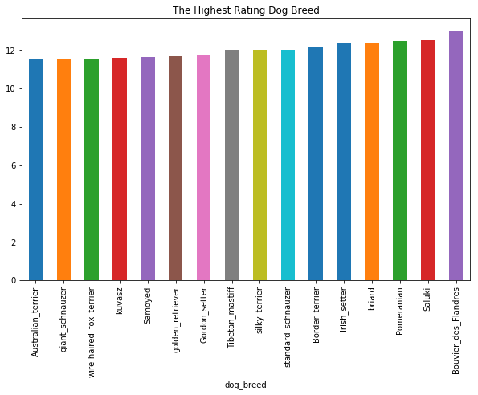

```python
df_highratings['rating'].sort_values().plot(kind = "bar", figsize = (10,6))
plt.title("The Highest Rating Dog Breed")
```

#### This seems gives us a clue how the @dog_rates actually rate dogs and what are their preferences. From the picture, we also can know the rating score difference are not so much for different dogs. This will make most tweet followers happy, which makes itself a successful twitter user.

### 3. The most favorite dog breed

```python
df_favorite_sorted = df_dog_breed_mean['favorite_count'].sort_values()

df_favorite_sorted
```

```
dog_breed
Brabancon_griffon                802.333333
groenendael                     1049.500000
Japanese_spaniel                1213.000000
Irish_wolfhound                 1387.000000
Tibetan_terrier                 1670.250000
standard_schnauzer              1834.000000
Scottish_deerhound              2072.000000
basenji                         2262.444444
Lhasa                           2404.200000
EntleBucher                     2429.000000
papillon                        2633.833333
Maltese_dog                     2668.052632
Saint_Bernard                   2785.333333
toy_terrier                     2890.666667
redbone                         2967.500000
English_setter                  2974.714286
soft-coated_wheaten_terrier     3019.000000
miniature_schnauzer             3108.000000
miniature_poodle                3134.750000
Dandie_Dinmont                  3147.857143
Scotch_terrier                  3238.000000
Shih-Tzu                        3251.600000
Ibizan_hound                    3412.200000
Sussex_spaniel                  3685.000000
Rhodesian_ridgeback             3693.000000
beagle                          3857.473684
dalmatian                       4065.636364
Yorkshire_terrier               4170.000000
curly-coated_retriever          4202.333333
keeshond                        4442.250000
                                   ...
kelpie                          9348.307692
German_shepherd                 9418.428571
Pembroke                        9592.904255
Labrador_retriever              9612.752475
Greater_Swiss_Mountain_dog      9651.333333
malamute                        9782.250000
Norwich_terrier                 9856.000000
bloodhound                     10096.428571
```

[output cut: 8 more lines]

```
Great_Pyrenees                 11263.200000
Eskimo_dog                     11826.590909
Mexican_hairless               12386.285714
Border_terrier                 12411.000000
whippet                        13452.545455
Leonberg                       13527.666667
English_springer               13653.777778
Irish_water_spaniel            14918.333333
flat-coated_retriever          15413.125000
black-and-tan_coonhound        15593.500000
Bouvier_des_Flandres           16393.000000
French_bulldog                 17199.896552
Saluki                         22116.000000
Bedlington_terrier             22895.833333
Name: favorite_count, Length: 112, dtype: float64
```

```python
# choosing the favorite counts higher than 10000 to simplify the visualization
df_highfavorite = df_dog_breed_mean[df_dog_breed_mean.favorite_count >= 10000]
```

```
Text(0.5,1,'The Most Favorite Dog Breed')
```

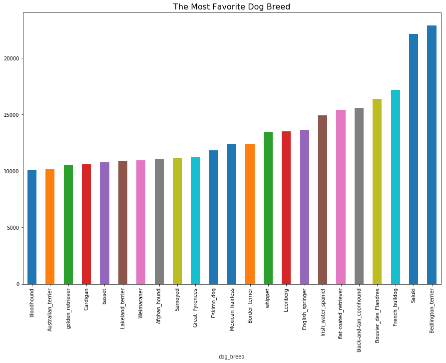

```python
df_highfavorite['favorite_count'].sort_values().plot(kind = "bar", figsize = (15,10))
plt.title("The Most Favorite Dog Breed", fontsize = 16)
```

#### This visualization shows this tweet followers hold slightly different views with the twitter user @dog_rates. This may attracts followers come to see and comment on its tweets.

### 4. The relationship between ratings and retweets

```
Text(0.5,1,'The relationship between rating and retweets')
```

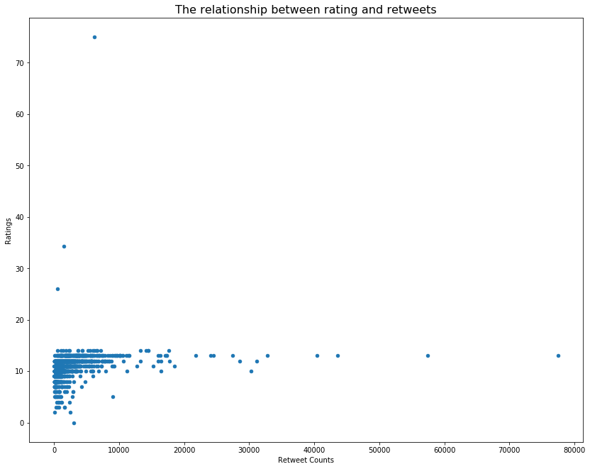

```python
df_twitter.plot(x='retweet_count', y='rating', kind='scatter', figsize = (14,11))
plt.xlabel('Retweet Counts')
plt.ylabel('Ratings')
plt.title("The relationship between rating and retweets", fontsize = 16)
```

#### Insight 4

#### The highest ratings do not necessarily mean the most retweets. The several outliers with high ratings did not make people retweets them. It indicates people have various preferences for dogs. The tweets with ratings between 10 and 15 get most retweets.

### 5. The most common dog names

```python
df_twitter.name.value_counts()
```

```
None              450
ChNonerlie         10
Lucy               10
Cooper             10
Oliver              9
Tucker              8
Winston             7
the                 7
SNonedie            7
Penny               7
DNoneisy            7
Toby                6
KodNone             6
JNonex              6
StNonenley          5
BellNone            5
OscNoner            5
LolNone             5
Leo                 5
JNoneck             4
Rusty               4
MNoneggie           4
Winnie              4
BNoneiley           4
Duke                4
Gus                 4
ONonekley           4
Chester             4
Dexter              4
Louis               4
                 ...
Oshie               1
GustNonev           1
KNoneiNone          1
RinnNone            1
CovNonech           1
Dido                1
O                   1
Timber              1
Christoper          1
AryNone             1
ShNonewwn           1
Juckson             1
NidNone             1
SNonensNone         1
SNonendy            1
infuriNoneting      1
Fred                1
Alf                 1
Rilo                1
Jockson             1
Vixen               1
Kulet               1
Cupid               1
Snickers            1
BubbNone            1
SNonege             1
Smiley              1
TNonessy            1
Monkey              1
Donny               1
Name: name, Length: 827, dtype: int64
```

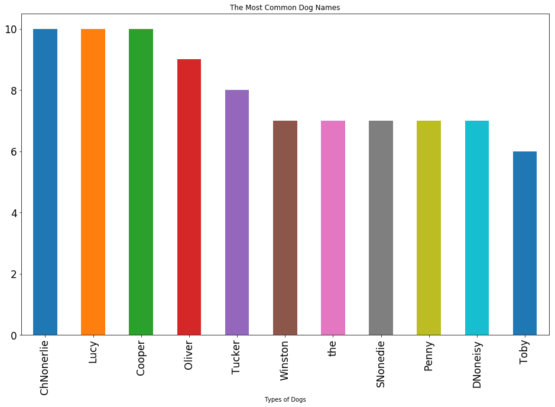

```python
# None is not right dog names, we get the picture after dropping the value.

df_twitter.name.value_counts()[1:12].plot('bar', figsize=(16,10), title='The Most Common Dog Names',fontsize = 17).set_xlabel("Types of Dogs");
```

#### The most popular dog names are Lucy, Cooper and ChNonerlie(all are 10), then are Oliver(9) and Tucker(8).

### 6. The relationship between favorite count and retweet count

```
Text(0.5,1,'Retweets and Likes Scatter Plot')
```

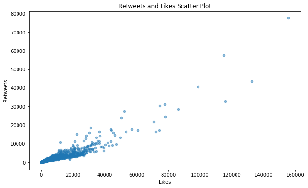

```python
df_twitter.plot(kind='scatter',x='favorite_count',y='retweet_count', figsize = (10,6),alpha = 0.5)
plt.xlabel('Likes')
plt.ylabel('Retweets')
plt.title('Retweets and Likes Scatter Plot')
```

#### In line with the assumption, favorite counts and retweet counts are highly positive related.

### 7. The best month to get tweet favorites

```python
df_favorite_mean = df_twitter.groupby('month').favorite_count.mean()
```

```python
df_favorite_mean
```

```
month
1      6864.823834
2      8246.059211
3      8048.557823
4     11096.036145
5     14277.382716
6     16462.235849
7     14834.330579
8      8511.431818
9      9283.520833
10    10944.700000
11     2586.000000
12     4429.480363
Name: favorite_count, dtype: float64
```

```python
df_favorite = df_twitter.groupby('month').mean()
```

```python
df_favorite
```

| month | tweet_id | in_reply_to_status_id | rating_numerator | rating_denominator | year | day | rating | img_num | p1_conf | p2_conf | p3_conf | favorite_count | retweet_count | followers_count | friends_count |
| --- | --- | --- | --- | --- | --- | --- | --- | --- | --- | --- | --- | --- | --- | --- | --- |
| 1 | 7.251455e+17 | 6.869153e+17 | 12.533679 | 11.450777 | 2016.279793 | 15.295337 | 10.906736 | 1.212435 | 0.590092 | 0.134662 | 0.063178 | 6864.823834 | 2132.186528 | 8.781598e+06 | 16.0 |
| 2 | 7.487479e+17 | 6.830199e+17 | 11.625000 | 10.460526 | 2016.375000 | 14.559211 | 11.092105 | 1.309211 | 0.571253 | 0.137160 | 0.067418 | 8246.059211 | 2095.401316 | 8.781599e+06 | 16.0 |
| 3 | 7.486066e+17 | 7.098359e+17 | 12.449664 | 11.275168 | 2016.295302 | 14.644295 | 11.147651 | 1.234899 | 0.657805 | 0.129662 | 0.055951 | 8048.557823 | 2099.496599 | 8.781594e+06 | 16.0 |
| 4 | 7.748734e+17 | 8.558181e+17 | 11.204819 | 10.000000 | 2016.409639 | 14.397590 | 11.204819 | 1.349398 | 0.622274 | 0.126496 | 0.063358 | 11096.036145 | 2852.204819 | 8.781588e+06 | 16.0 |
| 5 | 7.889584e+17 | 6.671522e+17 | 11.716049 | 10.000000 | 2016.432099 | 15.111111 | 11.716049 | 1.345679 | 0.612427 | 0.143720 | 0.057582 | 14277.382716 | 3732.530864 | 8.781587e+06 | 16.0 |
| 6 | 7.941193e+17 | 6.914169e+17 | 11.149533 | 10.000000 | 2016.383178 | 16.102804 | 11.149533 | 1.280374 | 0.635500 | 0.133396 | 0.055279 | 16462.235849 | 4688.566038 | 8.781588e+06 | 16.0 |
| 7 | 8.027728e+17 | NaN | 12.745902 | 11.147541 | 2016.368852 | 15.221311 | 11.483607 | 1.336066 | 0.648047 | 0.128508 | 0.056510 | 14834.330579 | 3546.570248 | 8.781595e+06 | 16.0 |
| 8 | 7.684919e+17 | NaN | 11.204545 | 10.000000 | 2016.022727 | 15.931818 | 11.204545 | 1.204545 | 0.616338 | 0.145839 | 0.049197 | 8511.431818 | 2536.181818 | 8.781564e+06 | 16.0 |
| 9 | 7.761866e+17 | NaN | 11.020408 | 10.000000 | 2016.000000 | 14.306122 | 11.020408 | 1.448980 | 0.602992 | 0.155839 | 0.063627 | 9283.520833 | 2864.729167 | 8.781562e+06 | 16.0 |
| 10 | 7.882114e+17 | NaN | 12.880000 | 10.000000 | 2016.000000 | 17.480000 | 12.880000 | 1.560000 | 0.695978 | 0.129704 | 0.045495 | 10944.700000 | 3324.160000 | 8.781561e+06 | 16.0 |
| 11 | 6.883264e+17 | 7.004580e+17 | 9.813688 | 10.000000 | 2015.152091 | 21.425856 | 9.813688 | 1.041825 | 0.558108 | 0.150544 | 0.069499 | 2586.000000 | 864.749049 | 8.781639e+06 | 16.0 |
| 12 | 6.963730e+17 | 6.740481e+17 | 11.036145 | 10.533133 | 2015.150602 | 14.156627 | 10.437608 | 1.093373 | 0.599703 | 0.130818 | 0.060128 | 4429.480363 | 1537.688822 | 8.781624e+06 | 16.0 |

```
Text(0.5,1,'The Best Time to produce favorite tweets')
```

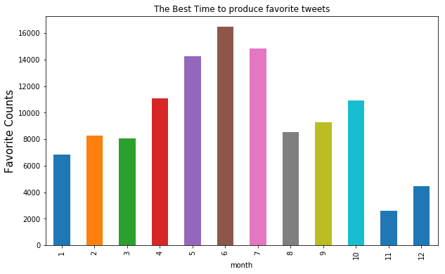

```python
df_favorite['favorite_count'].plot(kind = "bar",figsize = (10,6))
plt.ylabel("Favorite Counts",fontsize = 15)
plt.title("The Best Time to produce favorite tweets")
```

```
Text(0.5,1,'The Best Time to produce favorite tweets')
```

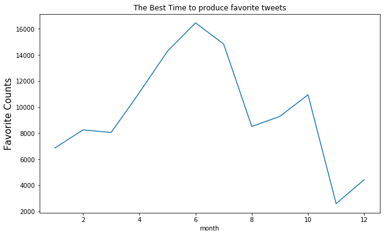

```python
# Using line chart may give more obvious trend information
df_favorite['favorite_count'].plot(kind = 'line',figsize = (10,6))
plt.ylabel("Favorite Counts",fontsize = 15)
plt.title("The Best Time to produce favorite tweets")
```

#### Insight 5

#### Clearly, the best time to get "likes" is June. The second best time is July, then comes the May. If considering from the perspective of period, the period from August to October is another good season to attract more "likes". November is the month with lowest favorite counts.

#### This indication is in line with peoples' outdoor activity habits. In summer and autumn, people tend to have more time to go out with their dogs and they click "likes" more frequently on the tweets of @ dog_rates.